# Brexit elasticities core results documentation

# Prepare the dataset

This chunk loads the main data set once and prepares the analysis sample. The Excel file containing the full applicant data set is imported (it is also pre-filtered). Two country groups are defined: EU member states (`eu_real`), the treated group, and a synthetic comparison set (`eu_synth`) used as the control pool. From the single read we build two frames. `panel_main` holds the baseline treated-plus-synthetic sample used by the headline models, and `apps_clean` holds the full cleaned panel restricted to years after 2015, used later for the donor-pool robustness checks.

```r
library(readxl)
library(dplyr)
# Read the applicant data ONCE. Everything downstream references this object.
apps_raw <- read_excel(
  "data_filtered.xlsx",
  sheet = "full_data"
)

eu_real <- c(
  "Austria", "Belgium", "Bulgaria", "Croatia", "Cyprus (European Union)",
  "Czech Republic", "Denmark", "Estonia", "Finland", "France",
  "Germany", "Greece", "Hungary",  "Italy",
  "Latvia", "Lithuania", "Luxembourg", "Malta", "Netherlands",
  "Poland", "Portugal", "Romania", "Slovakia", "Slovenia",
  "Spain", "Sweden"
)
```

```r
# Path to the control-group construction output. Defined once here so it is not
# repeated. Make this relative if you move the bundle to another machine.
control_group_file <- "~/GitHub/Estimating_price_elasticity/Statistical_documentation_in_R/Control_group_construction/control_group_output.xlsx"

# Read the donor/weights sheet ONCE.
donor_raw <- read_excel(control_group_file, sheet = "weights")

eu_synth <- donor_raw$donor_country

# Synthetic donors carry their computed regression weight; treated EU countries
# get weight 1. Stack the two into a single lookup keyed on country name.
regression_weights <- donor_raw %>%
  select(Domicile_named_country = donor_country, regression_weight) %>%
  bind_rows(
    tibble(Domicile_named_country = eu_real, regression_weight = 1)
  )
```

```r
# Full cleaned panel (all countries present in the file, post-2015).
# Used by the donor-pool robustness section.
apps_clean <- apps_raw %>%
  filter(Year > 2015) %>%
  mutate(
    Domicile_named_country = as.character(Domicile_named_country),
    Year    = as.integer(Year),
    EU      = as.integer(Domicile_named_country %in% eu_real),
    Post    = as.integer(Year >= 2021),
    log_app = log(Applicants)
  )
```

```r
# panel_main: the baseline treated + synthetic analysis frame, built ONCE.
# This single object replaces every later "df <- data_UCAS" copy and in-place
# mutation. All headline models read from it without modifying it.
panel_main <- apps_raw %>%
  filter(Domicile_named_country %in% c(eu_real, eu_synth)) %>%
  mutate(
    Domicile_named_country = as.character(Domicile_named_country),
    Year       = as.integer(Year),
    log_app    = log(Applicants),
    EU         = as.integer(Domicile_named_country %in% eu_real),
    Treated    = as.integer(Domicile_named_country %in% eu_real),
    Post       = as.integer(Year >= 2021),     # post-Brexit
    event_time = Year - 2020,                   # l = t - 2020
    EU_group   = if_else(Domicile_named_country %in% eu_real,
                         "Real_EU", "Synthetic_EU"),
    # each treated country keeps its own label, all controls pooled as CONTROL
    treated_factor = factor(if_else(Treated == 1,
                                    Domicile_named_country, "CONTROL"))
  ) %>%
  left_join(regression_weights, by = "Domicile_named_country")

# Every treated and synthetic country has a weight, so the join adds no NA.
# Fail loudly if that assumption ever breaks.
stopifnot(!anyNA(panel_main$regression_weight))
```

```r
# sanity checks
print(unique(panel_main$Domicile_named_country))
```

```
##  [1] "Austria"                      "Belgium"
##  [3] "Bulgaria"                     "Denmark"
##  [5] "Finland"                      "France"
##  [7] "Germany"                      "Greece"
##  [9] "Hungary"                      "Ireland"
## [11] "Italy"                        "Luxembourg"
## [13] "Malta"                        "Netherlands"
## [15] "Poland"                       "Portugal"
## [17] "Romania"                      "Spain"
## [19] "Sweden"                       "Estonia"
## [21] "Latvia"                       "Lithuania"
## [23] "Croatia"                      "Slovenia"
## [25] "Czech Republic"               "Slovakia"
## [27] "Cyprus (European Union)"      "Russian Federation"
## [29] "Mauritius"                    "Mexico"
## [31] "New Zealand"                  "Norway"
## [33] "Qatar"                        "Zimbabwe"
## [35] "Switzerland"                  "Tanzania, United Republic of"
## [37] "Trinidad and Tobago"          "United Arab Emirates"
## [39] "Turkey"                       "Uganda"
## [41] "Egypt"                        "United States of America"
## [43] "Australia"                    "Botswana"
## [45] "Brunei Darussalam"            "China"
## [47] "Indonesia"                    "Iran, Islamic Republic of"
## [49] "Israel"                       "Korea, Republic of"
## [51] "Lebanon"                      "Malaysia"
```

```r
table(panel_main$EU_group)
```

```
##
##      Real_EU Synthetic_EU
##          260          260
```

```r
head(panel_main)
```

| Year | Domicile_named_country | Applicants | Accepted_applicants | Acceptance_rate | Applicants_with_no_applications | log_app | EU | Treated | Post | event_time | EU_group | treated_factor | regression_weight |
| --- | --- | --- | --- | --- | --- | --- | --- | --- | --- | --- | --- | --- | --- |
| 2016 | Austria | 650 | 370 | 0.5670000000000001 | 5 | 6.476972 | 1 | 1 | 0 | -4 | Real_EU | Austria | 1 |
| 2017 | Austria | 590 | 340 | 0.5710000000000001 | 0 | 6.380123 | 1 | 1 | 0 | -3 | Real_EU | Austria | 1 |
| 2018 | Austria | 625 | 335 | 0.537 | 0 | 6.437752 | 1 | 1 | 0 | -2 | Real_EU | Austria | 1 |
| 2019 | Austria | 625 | 345 | 0.551 | 0 | 6.437752 | 1 | 1 | 0 | -1 | Real_EU | Austria | 1 |
| 2020 | Austria | 550 | 295 | 0.535 | 0 | 6.309918 | 1 | 1 | 0 | 0 | Real_EU | Austria | 1 |
| 2021 | Austria | 405 | 165 | 0.41300000000000003 | 0 | 6.003887 | 1 | 1 | 1 | 1 | Real_EU | Austria | 1 |

260/10 = 26 real European countries (excl. Ireland because it didn’t face the same restrictions (-1) and excluding UK for obvious reasons (-1)) and 260/10 = 26 synthetic countries (including Ireland because it is the most plausible counter-factual).

#For STATA replication

```r
#For stata replication checks
#library(haven)
#write_dta(
#  panel_main %>%
#    mutate(treated_factor = as.character(treated_factor)),
#  "panel_main.dta"
#)
```

# Saturated DID

## S-DID design with DK errors

This chunk estimates a pooled difference-in-differences model using `fixest::feols` with Driscoll–Kraay (DK) standard errors. `Post = 1` for years ≥ 2021 and treatment status `Treated = 1` for countries in `eu_real`. To allow heterogeneous post effects for each treated country while pooling all non-treated units, `treated_factor` gives each treated country its own label while all controls are set to `"CONTROL"` (the reference category).

We estimate four specifications: a two-way fixed-effects model with country and year fixed effects (`m_sat_DK`), a country fixed-effects-only model (`m_sat_DK1`), a model without fixed effects (`m_sat_DK2`), all three weighted, and an unweighted two-way fixed-effects counterpart (`m_sat_DK3`). Model summaries are printed for comparison.

The interaction term `i(treated_factor, Post, ref = "CONTROL")` estimates a separate post-treatment effect for each treated country relative to the pooled control group. Formally,

$$\log(Applicants_{it}) =
\alpha_i + \lambda_t +
\sum_{c \in \mathcal{T}} \beta_c
\left( \mathbf{1}\{i = c\} \times Post_t \right)
+ \varepsilon_{it},$$

where $i$ indexes countries and $t$ indexes years, $\alpha_i$ and $\lambda_t$ denote country and year fixed effects, $\mathcal{T}$ is the set of treated (EU) countries, and $Post_t$ equals 1 for $t \geq 2021$.  
Each coefficient $\beta_c$ captures the post-Brexit change in applications for treated country $c$ relative to the pooled control group.

### Models

```r
library(fixest)

m_sat_DK <- feols(
  log_app ~ i(treated_factor, Post, ref = "CONTROL") |
    Domicile_named_country + Year,
  data = panel_main,
  panel.id = ~ Domicile_named_country + Year,
  vcov = "DK",
  weights = ~ regression_weight
)
m_sat_DK1 <- feols(
  log_app ~ i(treated_factor, Post, ref = "CONTROL") |
    Domicile_named_country,
  data = panel_main,
  panel.id = ~ Domicile_named_country + Year,
  vcov = "DK",
  weights = ~ regression_weight
)
m_sat_DK2 <- feols(
  log_app ~ i(treated_factor, Post, ref = "CONTROL"),
  data = panel_main,
  panel.id = ~ Domicile_named_country + Year,
  vcov = "DK",
  weights = ~ regression_weight
)
# unweighted two-way FE counterpart of m_sat_DK
m_sat_DK3 <- feols(
  log_app ~ i(treated_factor, Post, ref = "CONTROL") |
    Domicile_named_country + Year,
  data = panel_main,
  panel.id = ~ Domicile_named_country + Year,
  vcov = "DK"
)
summary(m_sat_DK)
```

```
## OLS estimation, Dep. Var.: log_app
## Observations: 520
## Weights: regression_weight
## Fixed-effects: Domicile_named_country: 52,  Year: 10
## Standard-errors: Driscoll-Kraay (L=1)
##                                               Estimate Std. Error   t value
## treated_factor::Austria:Post                 -0.548528   0.053467 -10.25920
## treated_factor::Belgium:Post                 -0.602651   0.066891  -9.00947
## treated_factor::Bulgaria:Post                -1.887140   0.132272 -14.26712
## treated_factor::Croatia:Post                 -1.654739   0.109943 -15.05089
## treated_factor::Cyprus (European Union):Post -0.902157   0.068073 -13.25288
## treated_factor::Czech Republic:Post          -1.137196   0.056224 -20.22601
## treated_factor::Denmark:Post                 -1.046497   0.110556  -9.46576
## treated_factor::Estonia:Post                 -1.447439   0.118992 -12.16418
## treated_factor::Finland:Post                 -1.756341   0.208046  -8.44206
## treated_factor::France:Post                  -0.597100   0.062242  -9.59320
## treated_factor::Germany:Post                 -0.681494   0.072889  -9.34975
## treated_factor::Greece:Post                  -0.865744   0.078847 -10.98000
## treated_factor::Hungary:Post                 -1.114462   0.077841 -14.31716
## treated_factor::Italy:Post                   -0.925031   0.113260  -8.16733
## treated_factor::Latvia:Post                  -1.511510   0.128186 -11.79154
## treated_factor::Lithuania:Post               -2.173107   0.280104  -7.75822
## treated_factor::Luxembourg:Post              -0.492889   0.047436 -10.39067
## treated_factor::Malta:Post                   -0.361673   0.045345  -7.97599
## treated_factor::Netherlands:Post             -0.534966   0.024207 -22.09988
## treated_factor::Poland:Post                  -1.668275   0.150711 -11.06938
## treated_factor::Portugal:Post                -0.939163   0.353432  -2.65727
## treated_factor::Romania:Post                 -1.711427   0.137499 -12.44687
## treated_factor::Slovakia:Post                -1.516320   0.120035 -12.63236
## treated_factor::Slovenia:Post                -1.279548   0.122302 -10.46223
## treated_factor::Spain:Post                   -0.507695   0.084074  -6.03863
## treated_factor::Sweden:Post                  -0.966843   0.141019  -6.85610
##                                                Pr(>|t|)
## treated_factor::Austria:Post                 2.8906e-06 ***
## treated_factor::Belgium:Post                 8.4649e-06 ***
## treated_factor::Bulgaria:Post                1.7416e-07 ***
## treated_factor::Croatia:Post                 1.0954e-07 ***
## treated_factor::Cyprus (European Union):Post 3.2905e-07 ***
## treated_factor::Czech Republic:Post          8.2226e-09 ***
## treated_factor::Denmark:Post                 5.6403e-06 ***
```

[output cut: 8 more lines]

```
## treated_factor::Lithuania:Post               2.8261e-05 ***
## treated_factor::Luxembourg:Post              2.5986e-06 ***
## treated_factor::Malta:Post                   2.2673e-05 ***
## treated_factor::Netherlands:Post             3.7577e-09 ***
## treated_factor::Poland:Post                  1.5268e-06 ***
## treated_factor::Portugal:Post                2.6163e-02 *
## treated_factor::Romania:Post                 5.6359e-07 ***
## treated_factor::Slovakia:Post                4.9658e-07 ***
## treated_factor::Slovenia:Post                2.4535e-06 ***
## treated_factor::Spain:Post                   1.9315e-04 ***
## treated_factor::Sweden:Post                  7.4224e-05 ***
## ---
## Signif. codes:  0 '***' 0.001 '**' 0.01 '*' 0.05 '.' 0.1 ' ' 1
## RMSE: 0.153434     Adj. R2: 0.980222
##                  Within R2: 0.820743
```

```r
summary(m_sat_DK1)
```

```
## OLS estimation, Dep. Var.: log_app
## Observations: 520
## Weights: regression_weight
## Fixed-effects: Domicile_named_country: 52
## Standard-errors: Driscoll-Kraay (L=1)
##                                               Estimate Std. Error   t value
## treated_factor::Austria:Post                 -0.525213   0.051336 -10.23088
## treated_factor::Belgium:Post                 -0.579336   0.063442  -9.13173
## treated_factor::Bulgaria:Post                -1.863825   0.128181 -14.54054
## treated_factor::Croatia:Post                 -1.631423   0.104907 -15.55111
## treated_factor::Cyprus (European Union):Post -0.878841   0.065872 -13.34175
## treated_factor::Czech Republic:Post          -1.113880   0.051462 -21.64482
## treated_factor::Denmark:Post                 -1.023182   0.104812  -9.76208
## treated_factor::Estonia:Post                 -1.424123   0.114933 -12.39094
## treated_factor::Finland:Post                 -1.733025   0.203662  -8.50931
## treated_factor::France:Post                  -0.573784   0.058507  -9.80705
## treated_factor::Germany:Post                 -0.658179   0.070529  -9.33203
## treated_factor::Greece:Post                  -0.842428   0.077894 -10.81507
## treated_factor::Hungary:Post                 -1.091146   0.074542 -14.63801
## treated_factor::Italy:Post                   -0.901715   0.110412  -8.16682
## treated_factor::Latvia:Post                  -1.488195   0.121586 -12.23985
## treated_factor::Lithuania:Post               -2.149792   0.270911  -7.93540
## treated_factor::Luxembourg:Post              -0.469574   0.040036 -11.72878
## treated_factor::Malta:Post                   -0.338357   0.048807  -6.93262
## treated_factor::Netherlands:Post             -0.511651   0.026023 -19.66118
## treated_factor::Poland:Post                  -1.644960   0.145599 -11.29785
## treated_factor::Portugal:Post                -0.915848   0.344613  -2.65761
## treated_factor::Romania:Post                 -1.688111   0.132957 -12.69669
## treated_factor::Slovakia:Post                -1.493004   0.118625 -12.58588
## treated_factor::Slovenia:Post                -1.256233   0.119899 -10.47740
## treated_factor::Spain:Post                   -0.484379   0.078836  -6.14415
## treated_factor::Sweden:Post                  -0.943527   0.137914  -6.84142
##                                                Pr(>|t|)
## treated_factor::Austria:Post                 2.9581e-06 ***
## treated_factor::Belgium:Post                 7.5800e-06 ***
## treated_factor::Bulgaria:Post                1.4776e-07 ***
## treated_factor::Croatia:Post                 8.2430e-08 ***
## treated_factor::Cyprus (European Union):Post 3.1067e-07 ***
## treated_factor::Czech Republic:Post          4.5172e-09 ***
## treated_factor::Denmark:Post                 4.3708e-06 ***
```

[output cut: 8 more lines]

```
## treated_factor::Lithuania:Post               2.3615e-05 ***
## treated_factor::Luxembourg:Post              9.3531e-07 ***
## treated_factor::Malta:Post                   6.8148e-05 ***
## treated_factor::Netherlands:Post             1.0556e-08 ***
## treated_factor::Poland:Post                  1.2847e-06 ***
## treated_factor::Portugal:Post                2.6148e-02 *
## treated_factor::Romania:Post                 4.7544e-07 ***
## treated_factor::Slovakia:Post                5.1251e-07 ***
## treated_factor::Slovenia:Post                2.4239e-06 ***
## treated_factor::Spain:Post                   1.6992e-04 ***
## treated_factor::Sweden:Post                  7.5456e-05 ***
## ---
## Signif. codes:  0 '***' 0.001 '**' 0.01 '*' 0.05 '.' 0.1 ' ' 1
## RMSE: 0.16524     Adj. R2: 0.977528
##                 Within R2: 0.86716
```

```r
summary(m_sat_DK2)
```

```
## OLS estimation, Dep. Var.: log_app
## Observations: 520
## Weights: regression_weight
## Standard-errors: Driscoll-Kraay (L=1)
##                                               Estimate Std. Error    t value
## (Intercept)                                   6.844256   0.031876 214.715370
## treated_factor::Austria:Post                 -0.960966   0.046116 -20.837922
## treated_factor::Belgium:Post                 -0.434023   0.059062  -7.348581
## treated_factor::Bulgaria:Post                -1.006537   0.100973  -9.968399
## treated_factor::Croatia:Post                 -2.572288   0.097994 -26.249372
## treated_factor::Cyprus (European Union):Post  0.254871   0.041951   6.075439
## treated_factor::Czech Republic:Post          -0.901080   0.051991 -17.331549
## treated_factor::Denmark:Post                 -1.609410   0.093206 -17.267259
## treated_factor::Estonia:Post                 -2.237300   0.104042 -21.503810
## treated_factor::Finland:Post                 -1.817244   0.174309 -10.425440
## treated_factor::France:Post                   1.178782   0.060298  19.549182
## treated_factor::Germany:Post                  0.652016   0.063170  10.321590
## treated_factor::Greece:Post                   0.105148   0.076921   1.366969
## treated_factor::Hungary:Post                 -1.031933   0.073385 -14.061913
## treated_factor::Italy:Post                    0.676484   0.097532   6.936005
## treated_factor::Latvia:Post                  -1.928388   0.121957 -15.811985
## treated_factor::Lithuania:Post               -1.411544   0.243767  -5.790541
## treated_factor::Luxembourg:Post              -1.236827   0.040282 -30.704347
## treated_factor::Malta:Post                   -2.335425   0.041300 -56.547338
## treated_factor::Netherlands:Post             -0.491491   0.036574 -13.438213
## treated_factor::Poland:Post                  -0.135468   0.141080  -0.960222
## treated_factor::Portugal:Post                -0.087101   0.320623  -0.271662
## treated_factor::Romania:Post                 -0.363229   0.129515  -2.804526
## treated_factor::Slovakia:Post                -1.570149   0.094139 -16.679105
## treated_factor::Slovenia:Post                -3.107744   0.093809 -33.128257
## treated_factor::Spain:Post                    0.964334   0.064771  14.888367
## treated_factor::Sweden:Post                  -0.629644   0.123749  -5.088060
##                                                Pr(>|t|)
## (Intercept)                                   < 2.2e-16 ***
## treated_factor::Austria:Post                 6.3202e-09 ***
## treated_factor::Belgium:Post                 4.3338e-05 ***
## treated_factor::Bulgaria:Post                3.6737e-06 ***
## treated_factor::Croatia:Post                 8.1610e-10 ***
## treated_factor::Cyprus (European Union):Post 1.8467e-04 ***
## treated_factor::Czech Republic:Post          3.1980e-08 ***
```

[output cut: 8 more lines]

```
## treated_factor::Latvia:Post                  7.1309e-08 ***
## treated_factor::Lithuania:Post               2.6257e-04 ***
## treated_factor::Luxembourg:Post              2.0193e-10 ***
## treated_factor::Malta:Post                   8.5147e-13 ***
## treated_factor::Netherlands:Post             2.9198e-07 ***
## treated_factor::Poland:Post                  3.6203e-01
## treated_factor::Portugal:Post                7.9201e-01
## treated_factor::Romania:Post                 2.0560e-02 *
## treated_factor::Slovakia:Post                4.4744e-08 ***
## treated_factor::Slovenia:Post                1.0246e-10 ***
## treated_factor::Spain:Post                   1.2037e-07 ***
## treated_factor::Sweden:Post                  6.5565e-04 ***
## ---
## Signif. codes:  0 '***' 0.001 '**' 0.01 '*' 0.05 '.' 0.1 ' ' 1
## RMSE: 0.99342   Adj. R2: 0.271791
```

```r
summary(m_sat_DK3)
```

```
## OLS estimation, Dep. Var.: log_app
## Observations: 520
## Fixed-effects: Domicile_named_country: 52,  Year: 10
## Standard-errors: Driscoll-Kraay (L=1)
##                                               Estimate Std. Error   t value
## treated_factor::Austria:Post                 -0.686029   0.080635  -8.50783
## treated_factor::Belgium:Post                 -0.740152   0.094412  -7.83960
## treated_factor::Bulgaria:Post                -2.024641   0.159779 -12.67153
## treated_factor::Croatia:Post                 -1.792240   0.131220 -13.65825
## treated_factor::Cyprus (European Union):Post -1.039658   0.097165 -10.69994
## treated_factor::Czech Republic:Post          -1.274697   0.065362 -19.50218
## treated_factor::Denmark:Post                 -1.183999   0.133662  -8.85814
## treated_factor::Estonia:Post                 -1.584940   0.145137 -10.92028
## treated_factor::Finland:Post                 -1.893842   0.234771  -8.06677
## treated_factor::France:Post                  -0.734601   0.086036  -8.53826
## treated_factor::Germany:Post                 -0.818996   0.101103  -8.10061
## treated_factor::Greece:Post                  -1.003245   0.104029  -9.64388
## treated_factor::Hungary:Post                 -1.251963   0.090236 -13.87425
## treated_factor::Italy:Post                   -1.062532   0.140053  -7.58665
## treated_factor::Latvia:Post                  -1.649011   0.146961 -11.22074
## treated_factor::Lithuania:Post               -2.310608   0.300380  -7.69228
## treated_factor::Luxembourg:Post              -0.630390   0.068423  -9.21314
## treated_factor::Malta:Post                   -0.499174   0.049198 -10.14613
## treated_factor::Netherlands:Post             -0.672468   0.047410 -14.18404
## treated_factor::Poland:Post                  -1.805776   0.165776 -10.89288
## treated_factor::Portugal:Post                -1.076664   0.365929  -2.94228
## treated_factor::Romania:Post                 -1.848928   0.158606 -11.65737
## treated_factor::Slovakia:Post                -1.653821   0.126215 -13.10320
## treated_factor::Slovenia:Post                -1.417050   0.148966  -9.51257
## treated_factor::Spain:Post                   -0.645196   0.086634  -7.44739
## treated_factor::Sweden:Post                  -1.104344   0.167432  -6.59577
##                                                Pr(>|t|)
## treated_factor::Austria:Post                 1.3493e-05 ***
## treated_factor::Belgium:Post                 2.6013e-05 ***
## treated_factor::Bulgaria:Post                4.8359e-07 ***
## treated_factor::Croatia:Post                 2.5385e-07 ***
## treated_factor::Cyprus (European Union):Post 2.0320e-06 ***
## treated_factor::Czech Republic:Post          1.1339e-08 ***
## treated_factor::Denmark:Post                 9.7212e-06 ***
## treated_factor::Estonia:Post                 1.7117e-06 ***
## treated_factor::Finland:Post                 2.0711e-05 ***
## treated_factor::France:Post                  1.3109e-05 ***
## treated_factor::Germany:Post                 2.0029e-05 ***
## treated_factor::Greece:Post                  4.8349e-06 ***
## treated_factor::Hungary:Post                 2.2171e-07 ***
## treated_factor::Italy:Post                   3.3732e-05 ***
## treated_factor::Latvia:Post                  1.3613e-06 ***
## treated_factor::Lithuania:Post               3.0239e-05 ***
## treated_factor::Luxembourg:Post              7.0474e-06 ***
## treated_factor::Malta:Post                   3.1708e-06 ***
## treated_factor::Netherlands:Post             1.8319e-07 ***
## treated_factor::Poland:Post                  1.7483e-06 ***
## treated_factor::Portugal:Post                1.6426e-02 *
## treated_factor::Romania:Post                 9.8511e-07 ***
## treated_factor::Slovakia:Post                3.6280e-07 ***
## treated_factor::Slovenia:Post                5.4152e-06 ***
## treated_factor::Spain:Post                   3.9029e-05 ***
## treated_factor::Sweden:Post                  9.9760e-05 ***
## ---
## Signif. codes:  0 '***' 0.001 '**' 0.01 '*' 0.05 '.' 0.1 ' ' 1
## RMSE: 0.173376     Adj. R2: 0.976761
##                  Within R2: 0.809857
```

## Event study

This chunk estimates an event-study difference-in-differences model. Treatment status is $EU_i=1$ for countries in `eu_real`, and event time is $\ell = t - 2020$, so $\ell=0$ corresponds to 2020. `i(event_time, EU, ref = 0)` estimates a full set of dynamic EU–control differences for each relative year $\ell$, normalized to zero at $\ell=0$. Country and year fixed effects are included, standard errors are clustered, and `iplot()` visualizes the dynamic coefficients.

$$\log(Applicants_{it})=\alpha_i+\lambda_t+\sum_{\ell\neq
0}\beta_{\ell}\Big(\mathbf{1}\{t-2020=\ell\}\times
EU_i\Big)+\varepsilon_{it},$$

where $\beta_{\ell}$ traces the dynamic EU–control difference in year $\ell$ relative to the baseline year $\ell=0$ (2020).

### Event graph

```r
m_event <- feols(
  log_app ~ i(event_time, EU, ref = 0) |
    Domicile_named_country + Year,
  data = panel_main,
  panel.id = ~ Domicile_named_country + Year,
  vcov = "cluster",
  weights = ~ regression_weight
)

summary(m_event)
```

```
## OLS estimation, Dep. Var.: log_app
## Observations: 520
## Weights: regression_weight
## Fixed-effects: Domicile_named_country: 52,  Year: 10
## Standard-errors: Clustered (Domicile_named_country)
##                    Estimate Std. Error   t value   Pr(>|t|)
## event_time::-4:EU -0.011058   0.069688 -0.158682 8.7455e-01
## event_time::-3:EU  0.000279   0.053101  0.005253 9.9583e-01
## event_time::-2:EU  0.002467   0.039843  0.061928 9.5086e-01
## event_time::-1:EU  0.012991   0.026020  0.499263 6.1974e-01
## event_time::1:EU  -0.759900   0.091820 -8.275972 5.3938e-11 ***
## event_time::2:EU  -1.103973   0.116829 -9.449456 8.5754e-13 ***
## event_time::3:EU  -1.209460   0.128023 -9.447227 8.6420e-13 ***
## event_time::4:EU  -1.222673   0.125288 -9.758874 2.9448e-13 ***
## event_time::5:EU  -1.243534   0.125716 -9.891596 1.8679e-13 ***
## ---
## Signif. codes:  0 '***' 0.001 '**' 0.01 '*' 0.05 '.' 0.1 ' ' 1
## RMSE: 0.224504     Adj. R2: 0.959255
##                  Within R2: 0.616219
```

```r
iplot(
  m_event,
  xlab = "Years relative to 2020",
  ylab = "Log difference in applications",
  ref.line = 0,
  main = "Event-study: EU vs synthetic control"
)
```

[figure not shown]

```r
# Quick Wald test to insure robustness
wald(m_event, c(
  "event_time::-4:EU",
  "event_time::-3:EU",
  "event_time::-2:EU",
  "event_time::-1:EU"
))
```

```
## Wald test, H0: joint nullity of event_time::-4:EU, event_time::-3:EU, event_time::-2:EU and event_time::-1:EU
##  stat = 0.159352, p-value = 0.958706, on 4 and 450 DoF, VCOV: Clustered (Domicile_named_country).
```

Interestingly, if we remove the clustering the following happens:

```r
etable(m_event, vcov = "iid")
```

|  |  | m_event |
| --- | --- | --- |
| 1 | Dependent Var.: | log_app |
| 2 |  |  |
| 3 | EU x event_time = -4 | -0.0111 (0.0947) |
| 4 | EU x event_time = -3 | 0.0003 (0.0947) |
| 5 | EU x event_time = -2 | 0.0025 (0.0947) |
| 6 | EU x event_time = -1 | 0.0130 (0.0947) |
| 7 | EU x event_time = 1 | -0.7599*** (0.0947) |
| 8 | EU x event_time = 2 | -1.104*** (0.0947) |
| 9 | EU x event_time = 3 | -1.209*** (0.0947) |
| 10 | EU x event_time = 4 | -1.223*** (0.0947) |

[output cut: 9 more lines]

Notice that the standard errors are equal everywhere. Under iid (homoskedastic) errors, the event-time dummies will have the same variance in this design, and therefore identical standard errors. That follows directly from the mechanics of OLS. With iid errors, the variance of each coefficient depends only on

$$Var(\hat{\delta}_l)=\sigma^2(X_l'X_l'^{-1})$$

and the second moment of the regressor, and since each event-time dummy has identical support and variance after fixed effects, their estimated variances must be the same.

### Placebo graph

This chunk implements a placebo event-study to test for spurious pre-treatment dynamics. A fake treatment year is set to 2018 and event time is $\ell = t - 2018$. `i(event_time_pl2018, EU, ref = -1)` normalizes the year immediately before the placebo treatment ($\ell=-1$) to zero. Standard errors are clustered at the country level.

$$\log(Applicants_{it}) =
\alpha_i + \lambda_t +
\sum_{\ell \neq -1} \beta_{\ell}
\left(\mathbf{1}\{t-2018=\ell\} \times EU_i\right)
+ \varepsilon_{it},$$

where the coefficients $\beta_{\ell}$ capture placebo EU–control differences relative to the pre-placebo year $\ell=-1$.

```r
# placebo event time (fake Brexit in 2018), built on a derived column, no overwrite
m_placebo_2018 <- feols(
  log_app ~ i(I(Year - 2018), EU, ref = -1) |
    Domicile_named_country + Year,
  data = panel_main,
  panel.id = ~ Domicile_named_country + Year,
  cluster = ~ Domicile_named_country,
  weights = ~ regression_weight
)

summary(m_placebo_2018)
```

```
## OLS estimation, Dep. Var.: log_app
## Observations: 520
## Weights: regression_weight
## Fixed-effects: Domicile_named_country: 52,  Year: 10
## Standard-errors: Clustered (Domicile_named_country)
##                        Estimate Std. Error   t value   Pr(>|t|)
## I(Year - 2018)::-2:EU -0.011337   0.029583 -0.383233 7.0314e-01
## I(Year - 2018)::0:EU   0.002188   0.035631  0.061419 9.5127e-01
## I(Year - 2018)::1:EU   0.012712   0.042399  0.299817 7.6554e-01
## I(Year - 2018)::2:EU  -0.000279   0.053101 -0.005253 9.9583e-01
## I(Year - 2018)::3:EU  -0.760179   0.109780 -6.924576 7.1610e-09 ***
## I(Year - 2018)::4:EU  -1.104252   0.124217 -8.889699 6.0844e-12 ***
## I(Year - 2018)::5:EU  -1.209739   0.139721 -8.658237 1.3803e-11 ***
## I(Year - 2018)::6:EU  -1.222952   0.136456 -8.962252 4.7114e-12 ***
## I(Year - 2018)::7:EU  -1.243813   0.140600 -8.846464 7.0877e-12 ***
## ---
## Signif. codes:  0 '***' 0.001 '**' 0.01 '*' 0.05 '.' 0.1 ' ' 1
## RMSE: 0.224504     Adj. R2: 0.959255
##                  Within R2: 0.616219
```

```r
iplot(
  m_placebo_2018,
  xlab = "Years relative to fake Brexit (2018)",
  ylab = "Log difference in applications",
  ref.line = 0,
  main = "Placebo event study: fake Brexit in 2018"
)
```

[figure not shown]

```r
# leads-only sample (pre-2021 only)
panel_pre <- panel_main %>% filter(Year < 2021)

m_leads_only <- feols(
  log_app ~ i(event_time, EU, ref = 0) |
    Domicile_named_country + Year,
  data = panel_pre,
  panel.id = ~ Domicile_named_country + Year,
  cluster = ~ Domicile_named_country,
  weights = ~ regression_weight
)

summary(m_leads_only)
```

```
## OLS estimation, Dep. Var.: log_app
## Observations: 260
## Weights: regression_weight
## Fixed-effects: Domicile_named_country: 52,  Year: 5
## Standard-errors: Clustered (Domicile_named_country)
##                    Estimate Std. Error   t value Pr(>|t|)
## event_time::-4:EU -0.011058   0.069552 -0.158993  0.87430
## event_time::-3:EU  0.000279   0.052997  0.005264  0.99582
## event_time::-2:EU  0.002467   0.039765  0.062049  0.95077
## event_time::-1:EU  0.012991   0.025969  0.500243  0.61906
## ---
## Signif. codes:  0 '***' 0.001 '**' 0.01 '*' 0.05 '.' 0.1 ' ' 1
## RMSE: 0.088293     Adj. R2: 0.991605
##                  Within R2: 0.001875
```

```r
iplot(
  m_leads_only,
  xlab = "Years relative to 2020",
  ylab = "Log difference in applications",
  ref.line = 0,
  main = "Leads-only test without anticipation"
)
```

[figure not shown]

```r
wald(m_leads_only, c(
  "event_time::-4:EU",
  "event_time::-3:EU",
  "event_time::-2:EU",
  "event_time::-1:EU"
))
```

```
## Wald test, H0: joint nullity of event_time::-4:EU, event_time::-3:EU, event_time::-2:EU and event_time::-1:EU
##  stat = 0.159978, p-value = 0.958275, on 4 and 200 DoF, VCOV: Clustered (Domicile_named_country).
```

## Saturated event study

```r
# sanity checks on the treated_factor levels carried by panel_main
levels(panel_main$treated_factor)
```

```
##  [1] "Austria"                 "Belgium"
##  [3] "Bulgaria"                "CONTROL"
##  [5] "Croatia"                 "Cyprus (European Union)"
##  [7] "Czech Republic"          "Denmark"
##  [9] "Estonia"                 "Finland"
## [11] "France"                  "Germany"
## [13] "Greece"                  "Hungary"
## [15] "Italy"                   "Latvia"
## [17] "Lithuania"               "Luxembourg"
## [19] "Malta"                   "Netherlands"
## [21] "Poland"                  "Portugal"
## [23] "Romania"                 "Slovakia"
## [25] "Slovenia"                "Spain"
## [27] "Sweden"
```

```r
length(levels(panel_main$treated_factor))
```

```
## [1] 27
```

```r
m_sat_event <- feols(
  log_app ~ i(event_time, treated_factor, ref = 0, ref2 = "CONTROL") |
    Domicile_named_country + Year,
  data = panel_main,
  panel.id = ~ Domicile_named_country + Year,
  vcov = "cluster",
  weights = ~ regression_weight
)
summary(m_sat_event)
```

```
## OLS estimation, Dep. Var.: log_app
## Observations: 520
## Weights: regression_weight
## Fixed-effects: Domicile_named_country: 52,  Year: 10
## Standard-errors: Clustered (Domicile_named_country)
##                                                         Estimate Std. Error
## event_time::-4:treated_factor::Austria                  0.133479   0.078287
## event_time::-4:treated_factor::Belgium                  0.068365   0.078287
## event_time::-4:treated_factor::Bulgaria                 0.228590   0.078287
## event_time::-4:treated_factor::Croatia                  0.021233   0.078287
## event_time::-4:treated_factor::Cyprus (European Union)  0.134203   0.078287
## event_time::-4:treated_factor::Czech Republic          -0.202353   0.078287
## event_time::-4:treated_factor::Denmark                  0.067521   0.078287
## event_time::-4:treated_factor::Estonia                  0.127693   0.078287
## event_time::-4:treated_factor::Finland                  0.291086   0.078287
## event_time::-4:treated_factor::France                  -0.010351   0.078287
## event_time::-4:treated_factor::Germany                  0.114845   0.078287
## event_time::-4:treated_factor::Greece                   0.005808   0.078287
## event_time::-4:treated_factor::Hungary                 -0.190761   0.078287
## event_time::-4:treated_factor::Italy                    0.159730   0.078287
## event_time::-4:treated_factor::Latvia                  -0.145693   0.078287
## event_time::-4:treated_factor::Lithuania                0.067190   0.078287
## event_time::-4:treated_factor::Luxembourg               0.013492   0.078287
## event_time::-4:treated_factor::Malta                   -0.071316   0.078287
## event_time::-4:treated_factor::Netherlands             -0.007049   0.078287
## event_time::-4:treated_factor::Poland                  -0.269142   0.078287
## event_time::-4:treated_factor::Portugal                -0.561143   0.078287
## event_time::-4:treated_factor::Romania                 -0.037594   0.078287
## event_time::-4:treated_factor::Slovakia                -0.254306   0.078287
## event_time::-4:treated_factor::Slovenia                 0.181536   0.078287
## event_time::-4:treated_factor::Spain                   -0.306931   0.078287
## event_time::-4:treated_factor::Sweden                   0.154356   0.078287
## event_time::-3:treated_factor::Austria                  0.089256   0.053015
## event_time::-3:treated_factor::Belgium                  0.094204   0.053015
## event_time::-3:treated_factor::Bulgaria                 0.176519   0.053015
## event_time::-3:treated_factor::Croatia                 -0.038936   0.053015
## event_time::-3:treated_factor::Cyprus (European Union)  0.250073   0.053015
## event_time::-3:treated_factor::Czech Republic          -0.167826   0.053015
## event_time::-3:treated_factor::Denmark                  0.167104   0.053015
## event_time::-3:treated_factor::Estonia                  0.043744   0.053015
```

[output cut: 659 more lines]

```
## event_time::5:treated_factor::Lithuania                ***
## event_time::5:treated_factor::Luxembourg               ***
## event_time::5:treated_factor::Malta                    ***
## event_time::5:treated_factor::Netherlands              ***
## event_time::5:treated_factor::Poland                   ***
## event_time::5:treated_factor::Portugal                 ***
## event_time::5:treated_factor::Romania                  ***
## event_time::5:treated_factor::Slovakia                 ***
## event_time::5:treated_factor::Slovenia                 ***
## event_time::5:treated_factor::Spain                    ***
## event_time::5:treated_factor::Sweden                   ***
## ---
## Signif. codes:  0 '***' 0.001 '**' 0.01 '*' 0.05 '.' 0.1 ' ' 1
## RMSE: 0.110151     Adj. R2: 0.980383
##                  Within R2: 0.907613
```

```r
library(broom)
library(stringr)
```

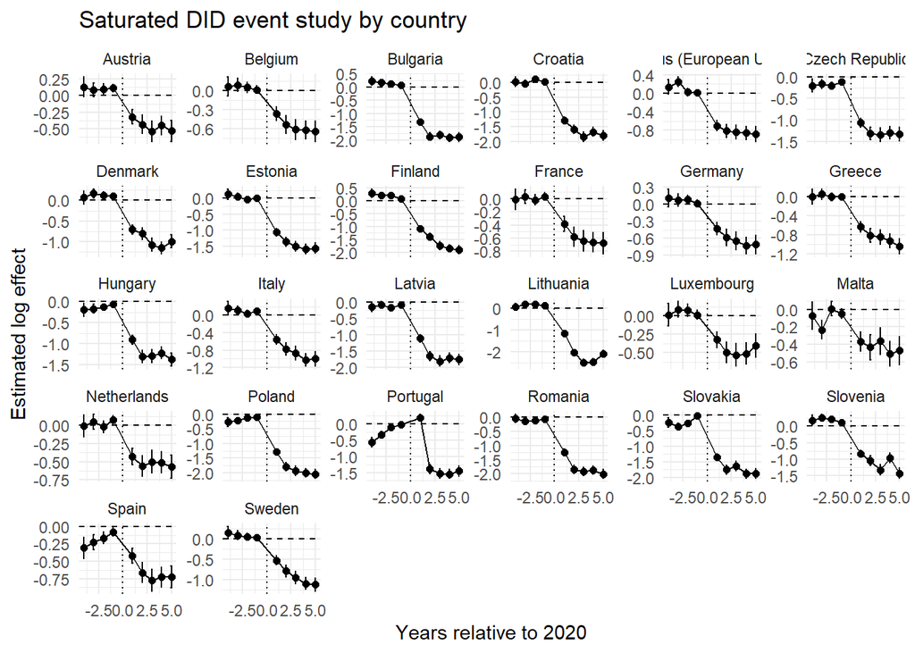

```r
library(ggplot2)

sat_event_plot <- broom::tidy(m_sat_event) %>%
  filter(str_detect(term, "^event_time::")) %>%
  mutate(
    event_time = as.integer(str_extract(term, "-?\\d+(?=:)")),
    country    = str_extract(term, "(?<=treated_factor::).*"),
    conf.low   = estimate - 1.96 * std.error,
    conf.high  = estimate + 1.96 * std.error
  ) %>%
  filter(!is.na(country), country != "CONTROL")

ggplot(sat_event_plot, aes(x = event_time, y = estimate)) +
  geom_hline(yintercept = 0, linetype = "dashed") +
  geom_vline(xintercept = 0, linetype = "dotted") +
  geom_point(size = 1.6) +
  geom_line() +
  geom_errorbar(aes(ymin = conf.low, ymax = conf.high), width = 0.15) +
  facet_wrap(~ country, scales = "free_y") +
  theme_minimal() +
  labs(
    x = "Years relative to 2020",
    y = "Estimated log effect",
    title = "Saturated DID event study by country"
  )
```

## D-El from S-DID compared with mechanical and fee based

```
## `height` was translated to `width`.
```

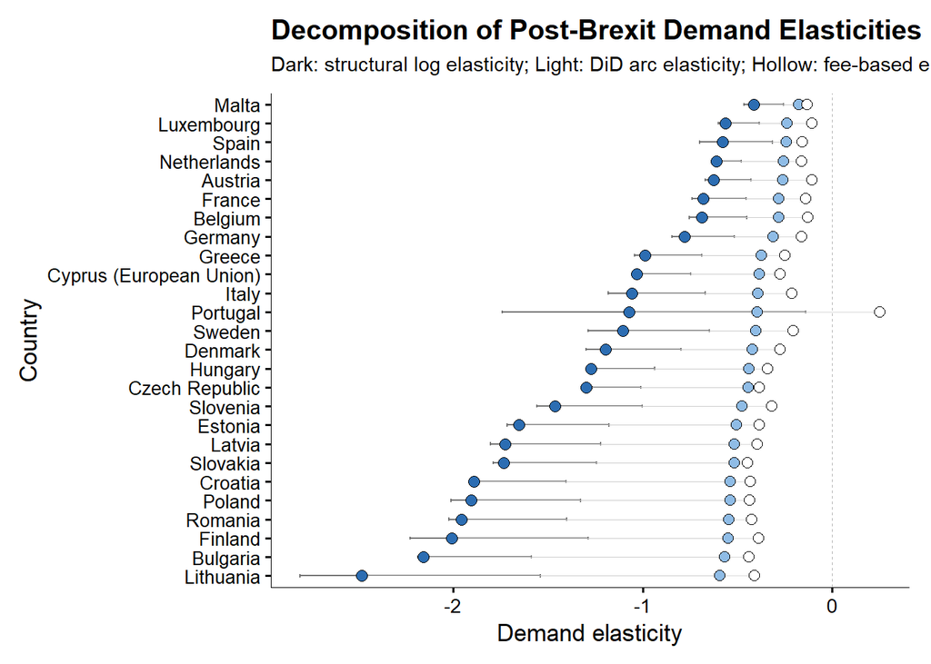

```r
library(ggplot2)
library(broom)

# 1. Brexit tuition shock. Two scalars, named for what they are:
fee_pre  <- 9250
fee_post <- 22200

log_fee_change   <- log(fee_post) - log(fee_pre)        # log price change, about 0.875
arith_fee_change <- (fee_post - fee_pre) / fee_pre      # arithmetic price change, about 1.40

# 2. Elasticities from the saturated DiD regression
decomp_did <- tidy(m_sat_DK, conf.int = TRUE) %>%
  filter(grepl("^treated_factor::", term)) %>%
  mutate(
    country = gsub("^treated_factor::", "", term),
    country = gsub(":Post$", "", country),

    beta = estimate,                 # delta log Q (DiD semi-elasticity)

    log_change    = beta,
    conf_low_log  = conf.low,
    conf_high_log = conf.high,

    eta_arc_did = (exp(beta) - 1) / arith_fee_change,   # arc elasticity
    eta_log     = beta / log_fee_change                 # structural log elasticity
  ) %>%
  select(country, log_change, conf_low_log, conf_high_log, eta_arc_did, eta_log)

# 3. Mechanical fee-based elasticity
fee_df <- panel_main %>%
  filter(Domicile_named_country %in% eu_real) %>%
  group_by(Domicile_named_country) %>%
  summarise(
    app_pre  = mean(Applicants[Year == 2020], na.rm = TRUE),
    app_post = mean(Applicants[Year == 2021], na.rm = TRUE),
    eta_mechanical = ((app_post - app_pre) / app_pre) / arith_fee_change,
    .groups = "drop"
  ) %>%
  rename(country = Domicile_named_country)

# 4. Merge
decomp_plot <- decomp_did %>%
  left_join(fee_df, by = "country") %>%
  arrange(eta_log) %>%
  mutate(
    country = factor(country, levels = country),
    eta_arc_shift  = eta_arc_did + 0.04,    # small offsets so points don't overlap
    eta_mech_shift = eta_mechanical + 0.08
  )

# 5. Plot
ggplot(decomp_plot, aes(y = country)) +
  geom_vline(xintercept = 0, linetype = "dashed", color = "grey70", linewidth = 0.35) +
  geom_errorbarh(
    aes(xmin = conf_low_log, xmax = conf_high_log),
    height = 0.16, linewidth = 0.4, color = "grey45"
  ) +
  geom_segment(aes(x = eta_log, xend = eta_arc_shift, yend = country),
               color = "grey80", linewidth = 0.3) +
  geom_segment(aes(x = eta_arc_shift, xend = eta_mech_shift, yend = country),
               color = "grey85", linewidth = 0.3) +
  geom_point(aes(x = eta_log),        shape = 21, size = 2.8, fill = "#2C6DB2", color = "black", stroke = 0.25) +
  geom_point(aes(x = eta_arc_shift),  shape = 21, size = 2.6, fill = "#8FBCE6", color = "black", stroke = 0.25) +
  geom_point(aes(x = eta_mech_shift), shape = 21, size = 2.6, fill = "white",   color = "black", stroke = 0.25) +
  labs(
    title = "Decomposition of Post-Brexit Demand Elasticities",
    subtitle = "Dark: structural log elasticity; Light: DiD arc elasticity; Hollow: fee-based elasticity",
    x = "Demand elasticity",
    y = "Country"
  ) +
  theme_classic(base_size = 13) +
  theme(
    plot.title = element_text(face = "bold", size = 15, margin = margin(b = 6)),
    plot.subtitle = element_text(size = 11, margin = margin(b = 10)),
    axis.text.y = element_text(size = 10),
    axis.line = element_line(linewidth = 0.35),
    plot.margin = margin(10, 12, 10, 10)
  )
```

## S-DID design DE with COVID and Post-COVID coefficients

The COVID design needs a different `Post` window, so it gets its own frame rather than overwriting the baseline `Post`. `Post` here flags the immediate 2021–2023 window (COVID and Brexit together) and `Post_COVID` flags the persistent 2024-onward response (Brexit only).

```r
panel_covid <- panel_main %>%
  mutate(
    Post       = as.integer(Year %in% c(2021, 2022, 2023)),
    Post_COVID = as.integer(Year >= 2024)
  )

m_sat_DK_2 <- feols(
  log_app ~
    i(treated_factor, Post, ref = "CONTROL") +
    i(treated_factor, Post_COVID, ref = "CONTROL") |
    Domicile_named_country + Year,
  data = panel_covid,
  panel.id = ~ Domicile_named_country + Year,
  vcov = "DK",
  weights = ~ regression_weight
)
summary(m_sat_DK_2)
```

```
## OLS estimation, Dep. Var.: log_app
## Observations: 520
## Weights: regression_weight
## Fixed-effects: Domicile_named_country: 52,  Year: 10
## Standard-errors: Driscoll-Kraay (L=1)
##                                                     Estimate Std. Error
## treated_factor::Austria:Post                       -0.524067   0.072802
## treated_factor::Belgium:Post                       -0.550705   0.078578
## treated_factor::Bulgaria:Post                      -1.795404   0.170652
## treated_factor::Croatia:Post                       -1.590864   0.159315
## treated_factor::Cyprus (European Union):Post       -0.869190   0.072415
## treated_factor::Czech Republic:Post                -1.106522   0.078669
## treated_factor::Denmark:Post                       -0.962495   0.115658
## treated_factor::Estonia:Post                       -1.341060   0.129467
## treated_factor::Finland:Post                       -1.570814   0.207865
## treated_factor::France:Post                        -0.542358   0.074103
## treated_factor::Germany:Post                       -0.614933   0.071119
## treated_factor::Greece:Post                        -0.778261   0.063159
## treated_factor::Hungary:Post                       -1.063983   0.112056
## treated_factor::Italy:Post                         -0.812768   0.103158
## treated_factor::Latvia:Post                        -1.428505   0.190838
## treated_factor::Lithuania:Post                     -2.025811   0.388700
## treated_factor::Luxembourg:Post                    -0.489585   0.066274
## treated_factor::Malta:Post                         -0.320710   0.040843
## treated_factor::Netherlands:Post                   -0.517777   0.030457
## treated_factor::Poland:Post                        -1.529203   0.176813
## treated_factor::Portugal:Post                      -0.704661   0.500286
## treated_factor::Romania:Post                       -1.603829   0.190492
## treated_factor::Slovakia:Post                      -1.397113   0.112325
## treated_factor::Slovenia:Post                      -1.229438   0.162514
## treated_factor::Spain:Post                         -0.464755   0.107384
## treated_factor::Sweden:Post                        -0.825067   0.127788
## treated_factor::Austria:Post_COVID                 -0.585221   0.032789
## treated_factor::Belgium:Post_COVID                 -0.680570   0.022214
## treated_factor::Bulgaria:Post_COVID                -2.024744   0.048970
## treated_factor::Croatia:Post_COVID                 -1.750551   0.039885
## treated_factor::Cyprus (European Union):Post_COVID -0.951608   0.056494
## treated_factor::Czech Republic:Post_COVID          -1.183205   0.045829
## treated_factor::Denmark:Post_COVID                 -1.172502   0.055563
## treated_factor::Estonia:Post_COVID                 -1.607007   0.033125
```

[output cut: 60 more lines]

```
## treated_factor::Lithuania:Post_COVID                -20.95665 6.0108e-09 ***
## treated_factor::Luxembourg:Post_COVID               -12.96263 3.9801e-07 ***
## treated_factor::Malta:Post_COVID                    -10.13610 3.1971e-06 ***
## treated_factor::Netherlands:Post_COVID              -27.04807 6.2506e-10 ***
## treated_factor::Poland:Post_COVID                   -32.44983 1.2326e-10 ***
## treated_factor::Portugal:Post_COVID                  -9.45108 5.7130e-06 ***
## treated_factor::Romania:Post_COVID                  -36.31208 4.5115e-11 ***
## treated_factor::Slovakia:Post_COVID                 -18.57939 1.7372e-08 ***
## treated_factor::Slovenia:Post_COVID                  -8.85977 9.7067e-06 ***
## treated_factor::Spain:Post_COVID                     -8.48817 1.3748e-05 ***
## treated_factor::Sweden:Post_COVID                   -35.75698 5.1780e-11 ***
## ---
## Signif. codes:  0 '***' 0.001 '**' 0.01 '*' 0.05 '.' 0.1 ' ' 1
## RMSE: 0.145451     Adj. R2: 0.981091
##                  Within R2: 0.838911
```

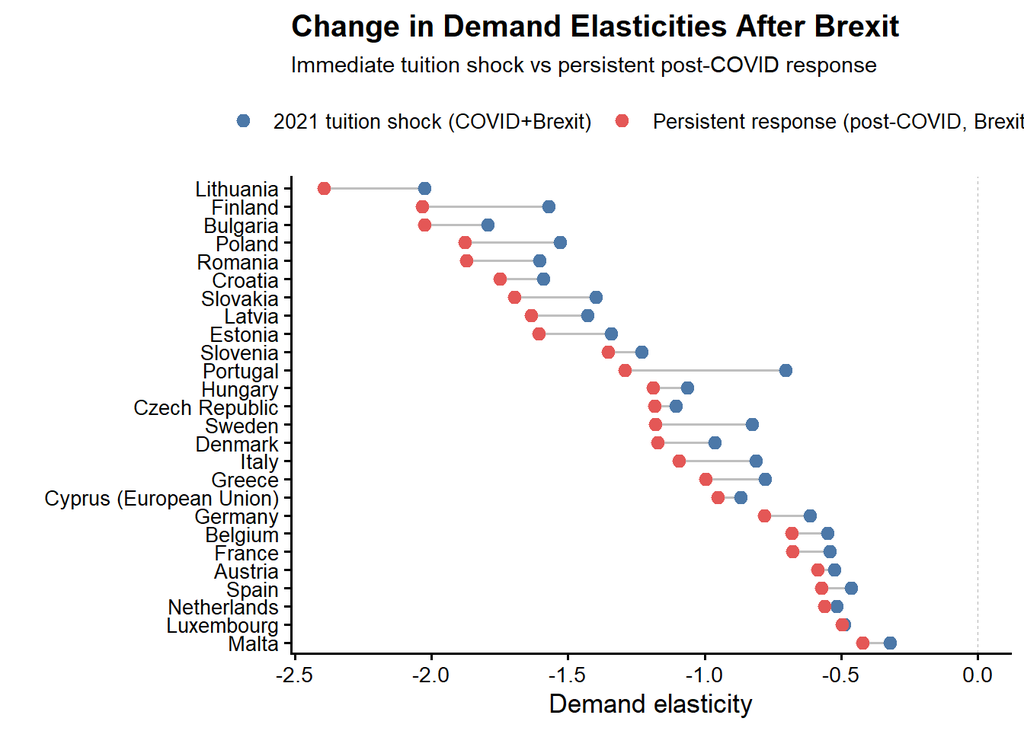

```r
library(tidyr)

# 1) extract coefficients
covid_coef <- tidy(m_sat_DK_2) %>%
  filter(str_detect(term, "^treated_factor::")) %>%
  mutate(
    period = case_when(
      str_detect(term, "Post_COVID$") ~ "Post-COVID",
      str_detect(term, "Post$")       ~ "Post-Brexit",
      TRUE ~ NA_character_
    ),
    country = term %>%
      str_remove("^treated_factor::") %>%
      str_remove(":(Post|Post_COVID)$"),
    elasticity = estimate
  ) %>%
  filter(!is.na(period))

# 2) wide version (for ordering + segments)
covid_wide <- covid_coef %>%
  select(country, period, elasticity) %>%
  pivot_wider(names_from = period, values_from = elasticity) %>%
  arrange(desc(`Post-COVID`)) %>%
  mutate(country = factor(country, levels = unique(country)))

# 3) long version (for legend + points)
covid_long <- covid_wide %>%
  pivot_longer(
    cols = c(`Post-Brexit`, `Post-COVID`),
    names_to = "period",
    values_to = "elasticity"
  ) %>%
  mutate(
    period = factor(
      period,
      levels = c("Post-Brexit", "Post-COVID"),
      labels = c(
        "2021 tuition shock (COVID+Brexit)",
        "Persistent response (post-COVID, Brexit only)"
      )
    )
  )

# 4) plot
ggplot(covid_long, aes(y = country)) +
  geom_segment(
    data = covid_wide,
    aes(x = `Post-Brexit`, xend = `Post-COVID`, yend = country),
    color = "grey75", linewidth = 0.6
  ) +
  geom_point(aes(x = elasticity, color = period), size = 2.6) +
  geom_vline(xintercept = 0, linetype = "dashed", color = "grey70", linewidth = 0.35) +
  scale_color_manual(values = c("#4C78A8", "#E45756"), name = NULL) +
  labs(
    title = "Change in Demand Elasticities After Brexit",
    subtitle = "Immediate tuition shock vs persistent post-COVID response",
    x = "Demand elasticity",
    y = ""
  ) +
  theme_classic(base_size = 13) +
  theme(
    plot.title = element_text(face = "bold", size = 15),
    plot.subtitle = element_text(size = 11),
    axis.text.y = element_text(size = 10),
    legend.position = "top",
    legend.text = element_text(size = 10)
  )
```

# Robustness P.I

## Step 1. Donor pools

```r
synth_poor <- c(
  "Pakistan", "Nepal", "Bangladesh", "Ethiopia", "Uganda",
  "Tanzania, United Republic of", "Rwanda", "Mozambique", "Malawi",
  "Sierra Leone", "Ghana", "Nigeria", "Kenya", "Zimbabwe"
)

synth_rich <- c(
  "United States of America", "Canada", "Australia", "Norway", "Switzerland",
  "Singapore", "Qatar", "United Arab Emirates", "Kuwait", "Saudi Arabia",
  "Israel", "Japan", "Hong Kong"
)

oecd <- c(
  "Australia", "Canada", "Chile", "Colombia", "Iceland", "Israel", "Japan",
  "Korea, Republic of", "Mexico", "New Zealand", "Norway", "Switzerland",
  "Turkey", "United States of America"
)
```

## Step 2. Analysis datasets

```r
data_baseline <- apps_clean %>%
  filter(Domicile_named_country %in% c(eu_real, eu_synth)) %>%
  mutate(control_group = "Baseline synthetic")

data_poor <- apps_clean %>%
  filter(Domicile_named_country %in% c(eu_real, synth_poor)) %>%
  mutate(control_group = "Very poor controls")

data_rich <- apps_clean %>%
  filter(Domicile_named_country %in% c(eu_real, synth_rich)) %>%
  mutate(control_group = "Very rich controls")

data_oecd <- apps_clean %>%
  filter(Domicile_named_country %in% c(eu_real, oecd)) %>%
  mutate(control_group = "OECD controls")
```

### Basic checks

```r
check_data <- function(dat) {
  data.frame(
    observations      = nrow(dat),
    countries         = length(unique(dat$Domicile_named_country)),
    eu_countries      = length(unique(dat$Domicile_named_country[dat$EU == 1])),
    control_countries = length(unique(dat$Domicile_named_country[dat$EU == 0])),
    first_year        = min(dat$Year, na.rm = TRUE),
    last_year         = max(dat$Year, na.rm = TRUE)
  )
}

data_checks <- bind_rows(
  "Baseline synthetic" = check_data(data_baseline),
  "Very poor controls" = check_data(data_poor),
  "Very rich controls" = check_data(data_rich),
  "OECD controls"      = check_data(data_oecd),
  .id = "sample"
)

data_checks
```

| sample | observations | countries | eu_countries | control_countries | first_year | last_year |
| --- | --- | --- | --- | --- | --- | --- |
| Baseline synthetic | 520 | 52 | 26 | 26 | 2016 | 2025 |
| Very poor controls | 400 | 40 | 26 | 14 | 2016 | 2025 |
| Very rich controls | 390 | 39 | 26 | 13 | 2016 | 2025 |
| OECD controls | 400 | 40 | 26 | 14 | 2016 | 2025 |

## Step 3. Construct donor-pool-specific weights

```r
make_distance_weights <- function(dat) {

  # Pre-treatment average EU trajectory
  eu_pre <- dat %>%
    filter(EU == 1, Year < 2021) %>%
    group_by(Year) %>%
    summarise(eu_mean_log_app = mean(log_app, na.rm = TRUE), .groups = "drop")

  # Distance of each control country from the EU pre-treatment path
  control_distances <- dat %>%
    filter(EU == 0, Year < 2021) %>%
    select(Domicile_named_country, Year, log_app) %>%
    left_join(eu_pre, by = "Year") %>%
    group_by(Domicile_named_country) %>%
    summarise(
      distance = sqrt(mean((log_app - eu_mean_log_app)^2, na.rm = TRUE)),
      .groups = "drop"
    ) %>%
    mutate(
      donor_weight = 1 / (distance + 0.001),
      donor_weight = donor_weight / mean(donor_weight, na.rm = TRUE)
    )

  # Treated EU countries get weight 1, controls get distance-based donor weights.
  dat %>%
    left_join(control_distances, by = "Domicile_named_country") %>%
    mutate(
      robustness_weight = ifelse(EU == 1, 1, donor_weight),
      robustness_weight = ifelse(is.na(robustness_weight), 1, robustness_weight)
    )
}
```

```r
data_baseline_w <- make_distance_weights(data_baseline)
data_poor_w     <- make_distance_weights(data_poor)
data_rich_w     <- make_distance_weights(data_rich)
data_oecd_w     <- make_distance_weights(data_oecd)
```

## Step 4. Weighted and unweighted DiD models

```r
run_weighted_unweighted <- function(dat) {
  m_weighted <- feols(
    log_app ~ EU:Post | Domicile_named_country + Year,
    data = dat,
    weights = ~ robustness_weight,
    panel.id = ~ Domicile_named_country + Year,
    vcov = "DK"
  )
  m_unweighted <- feols(
    log_app ~ EU:Post | Domicile_named_country + Year,
    data = dat,
    panel.id = ~ Domicile_named_country + Year,
    vcov = "DK"
  )
  list(weighted = m_weighted, unweighted = m_unweighted)
}
```

```r
models_baseline <- run_weighted_unweighted(data_baseline_w)
models_poor     <- run_weighted_unweighted(data_poor_w)
models_rich     <- run_weighted_unweighted(data_rich_w)
models_oecd     <- run_weighted_unweighted(data_oecd_w)
```

Next an Ireland-as-sole-control robustness check.

```r
eu_no_ireland <- setdiff(eu_real, "Ireland")  # eu_real has no Ireland, removed just in case

panel_ireland_pooled <- apps_clean %>%
  filter(Domicile_named_country %in% c(eu_no_ireland, "Ireland")) %>%
  mutate(
    EU   = as.integer(Domicile_named_country %in% eu_no_ireland),
    Post = as.integer(Year >= 2021),
    control_group = "IRELAND"
  )

m_ireland_only <- feols(
  log_app ~ EU:Post | Domicile_named_country + Year,
  data = panel_ireland_pooled,
  panel.id = ~ Domicile_named_country + Year,
  vcov = "DK"
)
```

```r
# Robustness table
etable(
  models_baseline$weighted, models_baseline$unweighted,
  models_poor$weighted,     models_poor$unweighted,
  models_rich$weighted,     models_rich$unweighted,
  models_oecd$weighted,     models_oecd$unweighted,
  m_ireland_only,
  dict = c("EU:Post" = "EU × Post"),
  headers = c(
    "Baseline weighted", "Baseline unweighted",
    "Poor weighted", "Poor unweighted",
    "Rich weighted", "Rich unweighted",
    "OECD weighted", "OECD unweighted",
    "Ireland only"
  ),
  fitstat = ~ n + ar2 + wr2,
  tex = FALSE
)
```

|  |  | models_baseline$.. | models_baseline$.. | models_poor$weig.. | models_poor$unwe.. | models_rich$weig.. | models_rich$unwe.. | models_oecd$weig.. | models_oecd$unwe.. | m_ireland_only |
| --- | --- | --- | --- | --- | --- | --- | --- | --- | --- | --- |
| 1 |  | Baseline weighted | Baseline unweighted | Poor weighted | Poor unweighted | Rich weighted | Rich unweighted | OECD weighted | OECD unweighted | Ireland only |
| 2 | Dependent Var.: | log_app | log_app | log_app | log_app | log_app | log_app | log_app | log_app | log_app |
| 3 |  |  |  |  |  |  |  |  |  |  |
| 4 | EU × Post | -1.195*** (0.1122) | -1.246*** (0.1203) | -1.653*** (0.1683) | -1.672*** (0.2039) | -1.350*** (0.1532) | -1.325*** (0.1342) | -1.215*** (0.1297) | -1.256*** (0.1303) | -1.315*** (0.1174) |
| 5 | Fixed-Effects: | ------------------ | ------------------ | ------------------ | ------------------ | ------------------ | ------------------ | ------------------ | ------------------ | ------------------ |
| 6 | Domicile_named_country | Yes | Yes | Yes | Yes | Yes | Yes | Yes | Yes | Yes |
| 7 | Year | Yes | Yes | Yes | Yes | Yes | Yes | Yes | Yes | Yes |
| 8 | ______________________ | __________________ | __________________ | __________________ | __________________ | __________________ | __________________ | __________________ | __________________ | __________________ |
| 9 | S.E. type | Drisco.-Kra. (L=1) | Drisco.-Kra. (L=1) | Drisco.-Kra. (L=1) | Drisco.-Kra. (L=1) | Drisco.-Kra. (L=1) | Drisco.-Kra. (L=1) | Drisco.-Kra. (L=1) | Drisco.-Kra. (L=1) | Drisco.-Kra. (L=1) |
| 10 | Observations | 520 | 520 | 400 | 400 | 390 | 390 | 400 | 400 | 270 |

[output cut: 2 more lines]

## Step 5. Plot basic DiD

```
## `height` was translated to `width`.
```

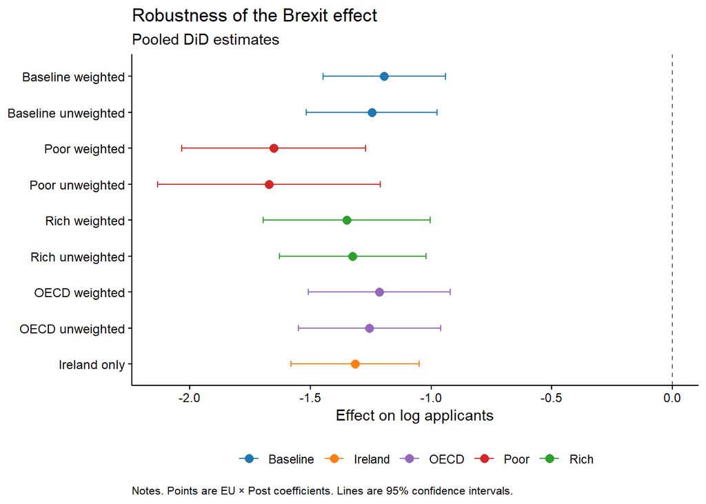

```r
basic_models <- list(
  "Baseline weighted"   = models_baseline$weighted,
  "Baseline unweighted" = models_baseline$unweighted,
  "Poor weighted"       = models_poor$weighted,
  "Poor unweighted"     = models_poor$unweighted,
  "Rich weighted"       = models_rich$weighted,
  "Rich unweighted"     = models_rich$unweighted,
  "OECD weighted"       = models_oecd$weighted,
  "OECD unweighted"     = models_oecd$unweighted,
  "Ireland only"        = m_ireland_only
)

basic_plot <- bind_rows(
  lapply(names(basic_models), function(x) {
    tidy(basic_models[[x]], conf.int = TRUE) %>%
      filter(term == "EU:Post") %>%
      mutate(model = x)
  })
) %>%
  mutate(
    model = factor(model, levels = rev(names(basic_models))),
    group = case_when(
      grepl("Baseline", model) ~ "Baseline",
      grepl("Poor", model)     ~ "Poor",
      grepl("Rich", model)     ~ "Rich",
      grepl("OECD", model)     ~ "OECD",
      grepl("Ireland", model)  ~ "Ireland",
      TRUE ~ "Other"
    )
  )

ggplot(basic_plot, aes(x = estimate, y = model, colour = group)) +
  geom_vline(xintercept = 0, linetype = "dashed", colour = "grey40") +
  geom_errorbarh(aes(xmin = conf.low, xmax = conf.high), height = 0.18) +
  geom_point(size = 2.7) +
  scale_colour_manual(values = c(
    "Baseline" = "#1F77B4", "Poor" = "#D62728", "Rich" = "#2CA02C",
    "OECD" = "#9467BD", "Ireland" = "#FF7F0E"
  )) +
  labs(
    title = "Robustness of the Brexit effect",
    subtitle = "Pooled DiD estimates",
    x = "Effect on log applicants",
    y = NULL, colour = NULL,
    caption = "Notes. Points are EU × Post coefficients. Lines are 95% confidence intervals."
  ) +
  theme_classic(base_size = 11) +
  theme(
    legend.position = "bottom",
    axis.text = element_text(size = 9),
    plot.caption = element_text(size = 8, hjust = 0)
  )
```

# Robustness P.II

## Step 1. Prepare the data

```r
prepare_saturated_data <- function(dat) {
  dat %>%
    mutate(
      treated_factor = factor(case_when(
        Domicile_named_country %in% eu_real ~ Domicile_named_country,
        TRUE ~ "CONTROL"
      ))
    )
}

data_baseline_sat <- prepare_saturated_data(data_baseline_w)
data_poor_sat     <- prepare_saturated_data(data_poor_w)
data_rich_sat     <- prepare_saturated_data(data_rich_w)
data_oecd_sat     <- prepare_saturated_data(data_oecd_w)
```

## Step 2. Run the saturated designs

```r
run_saturated_models <- function(dat) {
  m_weighted <- feols(
    log_app ~ i(treated_factor, Post, ref = "CONTROL") | Domicile_named_country + Year,
    data = dat,
    weights = ~ robustness_weight,
    panel.id = ~ Domicile_named_country + Year,
    vcov = "DK"
  )
  m_unweighted <- feols(
    log_app ~ i(treated_factor, Post, ref = "CONTROL") | Domicile_named_country + Year,
    data = dat,
    panel.id = ~ Domicile_named_country + Year,
    vcov = "DK"
  )
  list(weighted = m_weighted, unweighted = m_unweighted)
}
```

```r
sat_baseline <- run_saturated_models(data_baseline_sat)
sat_poor     <- run_saturated_models(data_poor_sat)
sat_rich     <- run_saturated_models(data_rich_sat)
sat_oecd     <- run_saturated_models(data_oecd_sat)
etable(sat_baseline, sat_poor, sat_rich, sat_oecd)
```

|  |  | weighted | unweighted | weighted | unweighted | weighted | unweighted | weighted | unweighted |
| --- | --- | --- | --- | --- | --- | --- | --- | --- | --- |
| 1 | Dependent Var.: | log_app | log_app | log_app | log_app | log_app | log_app | log_app | log_app |
| 2 |  |  |  |  |  |  |  |  |  |
| 3 | Post x treated_factor = Austria | -0.6347*** (0.0741) | -0.6860*** (0.0806) | -1.092*** (0.1389) | -1.112*** (0.1729) | -0.7893*** (0.1170) | -0.7649*** (0.0988) | -0.6542*** (0.0932) | -0.6956*** (0.0936) |
| 4 | Post x treated_factor = Belgium | -0.6888*** (0.0874) | -0.7402*** (0.0944) | -1.147*** (0.1504) | -1.166*** (0.1869) | -0.8434*** (0.1320) | -0.8191*** (0.1129) | -0.7083*** (0.1081) | -0.7497*** (0.1083) |
| 5 | Post x treated_factor = Bulgaria | -1.973*** (0.1529) | -2.025*** (0.1598) | -2.431*** (0.2174) | -2.450*** (0.2516) | -2.128*** (0.1971) | -2.104*** (0.1788) | -1.993*** (0.1724) | -2.034*** (0.1736) |
| 6 | Post x treated_factor = Croatia | -1.741*** (0.1223) | -1.792*** (0.1312) | -2.199*** (0.1832) | -2.218*** (0.2183) | -1.896*** (0.1657) | -1.871*** (0.1461) | -1.760*** (0.1400) | -1.802*** (0.1420) |
| 7 | Post x treated_factor = Cyprus(EuropeanUnion) | -0.9883*** (0.0932) | -1.040*** (0.0972) | -1.446*** (0.1540) | -1.465*** (0.1874) | -1.143*** (0.1335) | -1.119*** (0.1174) | -1.008*** (0.1135) | -1.049*** (0.1130) |
| 8 | Post x treated_factor = CzechRepublic | -1.223*** (0.0585) | -1.275*** (0.0654) | -1.681*** (0.1079) | -1.700*** (0.1426) | -1.378*** (0.0937) | -1.354*** (0.0756) | -1.243*** (0.0746) | -1.284*** (0.0731) |
| 9 | Post x treated_factor = Denmark | -1.133*** (0.1251) | -1.184*** (0.1337) | -1.590*** (0.1832) | -1.610*** (0.2213) | -1.287*** (0.1705) | -1.263*** (0.1507) | -1.152*** (0.1447) | -1.194*** (0.1459) |
| 10 | Post x treated_factor = Estonia | -1.534*** (0.1383) | -1.585*** (0.1451) | -1.991*** (0.1956) | -2.010*** (0.2341) | -1.688*** (0.1824) | -1.664*** (0.1633) | -1.553*** (0.1599) | -1.594*** (0.1585) |

[output cut: 26 more lines]

Saturated DID with Ireland as the only counterfactual. Weighting does not affect these coefficients, so it is left unweighted.

```r
panel_ireland <- apps_clean %>%
  filter(Domicile_named_country %in% c(eu_real, "Ireland"))

data_ireland_sat <- panel_ireland %>%
  mutate(
    treated_factor = factor(ifelse(
      Domicile_named_country %in% eu_real,   # eu_real does not contain Ireland either way
      Domicile_named_country,
      "IRELAND"
    )),
    regression_weight = ifelse(Domicile_named_country == "Ireland", 26, 1)
  )

sat_ireland_only <- feols(
  log_app ~ i(treated_factor, Post, ref = "IRELAND") | Domicile_named_country + Year,
  data = data_ireland_sat,
  panel.id = ~ Domicile_named_country + Year,
  vcov = "DK"
)
etable(
  sat_baseline$weighted, sat_baseline$unweighted,
  sat_poor$weighted,     sat_poor$unweighted,
  sat_rich$weighted,     sat_rich$unweighted,
  sat_oecd$weighted,     sat_oecd$unweighted,
  sat_ireland_only,
  headers = c(
    "Baseline weighted", "Baseline unweighted",
    "Poor weighted", "Poor unweighted",
    "Rich weighted", "Rich unweighted",
    "OECD weighted", "OECD unweighted",
    "Ireland only"
  ),
  fitstat = ~ n + ar2 + wr2,
  tex = FALSE
)
```

|  |  | sat_baseline$weig.. | sat_baseline$unwe.. | sat_poor$weighted | sat_poor$unweighted | sat_rich$weighted | sat_rich$unweighted | sat_oecd$weighted | sat_oecd$unweighted | sat_ireland_only |
| --- | --- | --- | --- | --- | --- | --- | --- | --- | --- | --- |
| 1 |  | Baseline weighted | Baseline unweighted | Poor weighted | Poor unweighted | Rich weighted | Rich unweighted | OECD weighted | OECD unweighted | Ireland only |
| 2 | Dependent Var.: | log_app | log_app | log_app | log_app | log_app | log_app | log_app | log_app | log_app |
| 3 |  |  |  |  |  |  |  |  |  |  |
| 4 | Post x treated_factor = Austria | -0.6347*** (0.0741) | -0.6860*** (0.0806) | -1.092*** (0.1389) | -1.112*** (0.1729) | -0.7893*** (0.1170) | -0.7649*** (0.0988) | -0.6542*** (0.0932) | -0.6956*** (0.0936) | -0.7545*** (0.0771) |
| 5 | Post x treated_factor = Belgium | -0.6888*** (0.0874) | -0.7402*** (0.0944) | -1.147*** (0.1504) | -1.166*** (0.1869) | -0.8434*** (0.1320) | -0.8191*** (0.1129) | -0.7083*** (0.1081) | -0.7497*** (0.1083) | -0.8086*** (0.0862) |
| 6 | Post x treated_factor = Bulgaria | -1.973*** (0.1529) | -2.025*** (0.1598) | -2.431*** (0.2174) | -2.450*** (0.2516) | -2.128*** (0.1971) | -2.104*** (0.1788) | -1.993*** (0.1724) | -2.034*** (0.1736) | -2.093*** (0.1408) |
| 7 | Post x treated_factor = Croatia | -1.741*** (0.1223) | -1.792*** (0.1312) | -2.199*** (0.1832) | -2.218*** (0.2183) | -1.896*** (0.1657) | -1.871*** (0.1461) | -1.760*** (0.1400) | -1.802*** (0.1420) | -1.861*** (0.1340) |
| 8 | Post x treated_factor = Cyprus(EuropeanUnion) | -0.9883*** (0.0932) | -1.040*** (0.0972) | -1.446*** (0.1540) | -1.465*** (0.1874) | -1.143*** (0.1335) | -1.119*** (0.1174) | -1.008*** (0.1135) | -1.049*** (0.1130) | -1.108*** (0.0689) |
| 9 | Post x treated_factor = CzechRepublic | -1.223*** (0.0585) | -1.275*** (0.0654) | -1.681*** (0.1079) | -1.700*** (0.1426) | -1.378*** (0.0937) | -1.354*** (0.0756) | -1.243*** (0.0746) | -1.284*** (0.0731) | -1.343*** (0.0898) |
| 10 | Post x treated_factor = Denmark | -1.133*** (0.1251) | -1.184*** (0.1337) | -1.590*** (0.1832) | -1.610*** (0.2213) | -1.287*** (0.1705) | -1.263*** (0.1507) | -1.152*** (0.1447) | -1.194*** (0.1459) | -1.252*** (0.1282) |

[output cut: 27 more lines]

## Step 3. Line plot comparing models

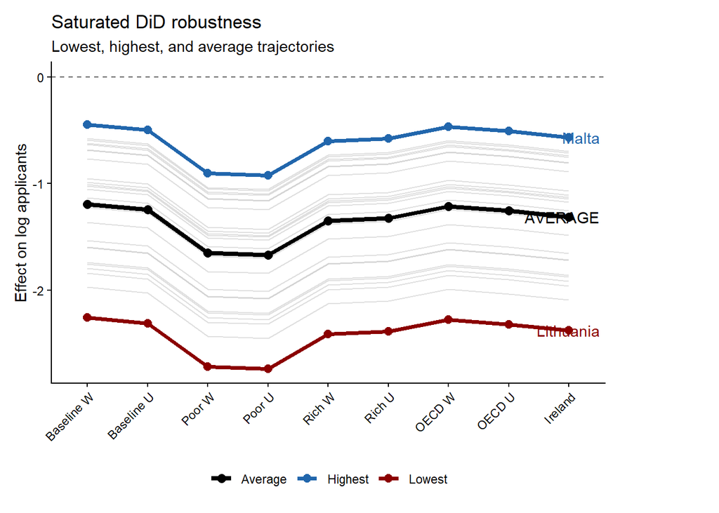

```r
library(ggrepel)

sat_models <- list(
  "Baseline W" = sat_baseline$weighted, "Baseline U" = sat_baseline$unweighted,
  "Poor W" = sat_poor$weighted,         "Poor U" = sat_poor$unweighted,
  "Rich W" = sat_rich$weighted,         "Rich U" = sat_rich$unweighted,
  "OECD W" = sat_oecd$weighted,         "OECD U" = sat_oecd$unweighted,
  "Ireland" = sat_ireland_only
)

sat_long <- bind_rows(lapply(names(sat_models), function(m) {
  tidy(sat_models[[m]], conf.int = TRUE) %>%
    filter(str_detect(term, "treated_factor::.*:Post")) %>%
    mutate(
      model = m,
      country = str_replace_all(term, "treated_factor::|:Post", "")
    )
}))

sat_long$model <- factor(sat_long$model, levels = names(sat_models))

ranked <- sat_long %>%
  group_by(country) %>%
  summarise(avg = mean(estimate), .groups = "drop") %>%
  arrange(avg)

low  <- ranked$country[1]
high <- ranked$country[nrow(ranked)]

sat_long <- sat_long %>%
  mutate(group = case_when(
    country == low  ~ "Lowest",
    country == high ~ "Highest",
    TRUE ~ "Other"
  ))

avg <- sat_long %>%
  group_by(model) %>%
  summarise(estimate = mean(estimate), .groups = "drop") %>%
  mutate(country = "AVERAGE", group = "Average")

labels <- bind_rows(
  sat_long %>% filter(country %in% c(low, high), model == "Ireland"),
  avg %>% filter(model == "Ireland")
)

ggplot() +
  geom_hline(yintercept = 0, linetype = "dashed", colour = "grey40") +
  geom_line(data = sat_long %>% filter(group == "Other"),
            aes(model, estimate, group = country), colour = "grey75", alpha = 0.5) +
  geom_line(data = sat_long %>% filter(group != "Other"),
            aes(model, estimate, group = country, colour = group), linewidth = 1.3) +
  geom_line(data = avg, aes(model, estimate, group = country, colour = group), linewidth = 1.5) +
  geom_point(data = sat_long %>% filter(group != "Other"),
             aes(model, estimate, colour = group), size = 2.4) +
  geom_point(data = avg, aes(model, estimate, colour = group), size = 2.6) +
  geom_text_repel(data = labels, aes(model, estimate, label = country, colour = group),
                  nudge_x = 0.4, hjust = 0, show.legend = FALSE) +
  scale_colour_manual(values = c("Lowest" = "#8B0000", "Highest" = "#2166AC", "Average" = "black")) +
  coord_cartesian(clip = "off") +
  labs(
    title = "Saturated DiD robustness",
    subtitle = "Lowest, highest, and average trajectories",
    x = NULL, y = "Effect on log applicants", colour = NULL
  ) +
  theme_classic(base_size = 11) +
  theme(
    axis.text.x = element_text(angle = 45, hjust = 1),
    legend.position = "bottom",
    plot.margin = margin(10, 80, 10, 10)
  )
```

# Controls for wealth heterogeneity

The wealth-heterogeneity panel is derived directly from `panel_main`, so it inherits `log_app`, `EU`, `Post`, and `regression_weight` without recomputation. We add the DiD interaction and merge in World Bank controls.

```r
panel_wb <- panel_main %>%
  mutate(did = EU * Post) %>%
  filter(!is.na(log_app))
```

Now a targeted pull from the World Bank API for:

- GDP per capita (real prices)
- Population aged 15 to 64
- Youth unemployment
- Government expenditure on education (% of GDP)

QS-ranked university counts are deliberately not pulled here, since the World Bank exposes no such series. That one stays a manual table for future work.

```r
library(WDI)
library(countrycode)

panel_countries <- unique(panel_wb$Domicile_named_country)

iso_map <- data.frame(Domicile_named_country = panel_countries) %>%
  mutate(
    iso2c = countrycode(
      Domicile_named_country, "country.name", "iso2c",
      custom_match = c("Cyprus (European Union)" = "CY"),
      warn = TRUE
    ),
    iso3c = countrycode(iso2c, "iso2c", "iso3c", warn = FALSE)
  )

# safety net, this should print zero rows
iso_map[is.na(iso_map$iso2c), ]
```

| Domicile_named_country | iso2c | iso3c |
| --- | --- | --- |

```r
wb_codes <- c(
  GDPpc       = "NY.GDP.PCAP.KD",    # GDP per capita, constant 2015 US$
  Pop15_65    = "SP.POP.1564.TO",    # population ages 15-64, total (band is 15-64)
  YouthUnempl = "SL.UEM.1524.ZS",    # unemployment, ages 15-24, modeled ILO
  EduSpendGDP = "SE.XPD.TOTL.GD.ZS"  # govt expenditure on education, % of GDP
)


#to check later:
#https://data.worldbank.org/indicator/NY.GDP.PCAP.KD?locations=LB-BG

yr_min <- min(panel_wb$Year, na.rm = TRUE)
yr_max <- max(panel_wb$Year, na.rm = TRUE)

wb_raw <- WDI(
  country   = na.omit(iso_map$iso2c),
  indicator = wb_codes,
  start     = yr_min,
  end       = yr_max
)


# Because GDP per capita and youth unemployment for Lebanon are missing we use the averages for the previous two years Y_2024=(Y_2023+Y_2022)/2 and Y_2025=(Y_2024+Y_2023)/2
wb_raw$GDPpc[
  wb_raw$country == "Lebanon" & wb_raw$year == 2024
] <- mean(
  wb_raw$GDPpc[
    wb_raw$country == "Lebanon" & wb_raw$year %in% c(2022, 2023)
  ],
  na.rm = TRUE
)

wb_raw$GDPpc[
  wb_raw$country == "Lebanon" & wb_raw$year == 2025
] <- mean(
  wb_raw$GDPpc[
    wb_raw$country == "Lebanon" & wb_raw$year %in% c(2023, 2024)
  ],
  na.rm = TRUE
)

wb_raw$YouthUnempl[wb_raw$country=="Lebanon" & wb_raw$year==2024]<-mean(wb_raw$YouthUnempl[wb_raw$country=="Lebanon" & wb_raw$year %in% c(2023,2022)])

wb_raw$YouthUnempl[wb_raw$country=="Lebanon" & wb_raw$year==2025]<-mean(wb_raw$YouthUnempl[wb_raw$country=="Lebanon" & wb_raw$year %in% c(2024,2023)])

wb_raw$GDPpc[
  wb_raw$country == "United Arab Emirates" &
  wb_raw$year == 2025
] <- mean(
  wb_raw$GDPpc[
    wb_raw$country == "Lebanon" &
    wb_raw$year %in% c(2023, 2024)
  ],
  na.rm = TRUE
)

wb_clean <- wb_raw %>%
  transmute(iso3c, Year = as.integer(year),
            GDPpc, Pop15_65, YouthUnempl, EduSpendGDP)
```

```r
panel_wb <- panel_wb %>%
  left_join(iso_map[, c("Domicile_named_country", "iso3c")],
            by = "Domicile_named_country") %>%
  left_join(wb_clean, by = c("iso3c", "Year"))

# Complete-case on the THREE controls the models consume. Education spend rides
# along but does NOT gate the sample (it is sparse for recent years and the Gulf).
panel_wb <- panel_wb %>%
  filter(!is.na(GDPpc), !is.na(Pop15_65), !is.na(YouthUnempl))
```

```r
# Quick inspection of the data in Excel
library(openxlsx)
write.xlsx(panel_wb, "panel_wb.xlsx")
```

Centre the three controls once. Centring is done on the log (for GDP and population), so models must reference the bare `c_*` variables and never wrap `log()` around them again.

```r
library(modelsummary)

panel_wb <- panel_wb %>%
  mutate(
    c_log_GDPpc    = log(GDPpc)    - mean(log(GDPpc),    na.rm = TRUE),
    c_log_Pop15_65 = log(Pop15_65) - mean(log(Pop15_65), na.rm = TRUE),
    c_YouthUnempl  = YouthUnempl   - mean(YouthUnempl,   na.rm = TRUE))

# M1 — clean baseline DiD
m1 <- feols(
  log_app ~ Treated:Post | Domicile_named_country + Year,
  data = panel_main, panel.id = ~ Domicile_named_country + Year,
  vcov = "DK", weights = ~ regression_weight
)

# M2 — add GDP
m2 <- feols(
  log_app ~ did + c_log_GDPpc | Domicile_named_country + Year,
  data = panel_wb, panel.id = ~ Domicile_named_country + Year,
  vcov = "DK", weights = ~ regression_weight
)

# M4 — add working-age population
m4 <- feols(
  log_app ~ did + c_log_GDPpc + c_log_Pop15_65 | Domicile_named_country + Year,
  data = panel_wb, panel.id = ~ Domicile_named_country + Year,
  vcov = "DK", weights = ~ regression_weight
)

# M5 — add youth unemployment
m5 <- feols(
  log_app ~ did + c_log_GDPpc + c_YouthUnempl + c_log_Pop15_65 | Domicile_named_country + Year,
  data = panel_wb, panel.id = ~ Domicile_named_country + Year,
  vcov = "DK", weights = ~ regression_weight
)

# M6 — fully interacted structural channels
m6 <- feols(
  log_app ~ did * (c_log_GDPpc + c_log_Pop15_65 + c_YouthUnempl) | Domicile_named_country + Year,
  data = panel_wb, panel.id = ~ Domicile_named_country + Year,
  vcov = "DK", weights = ~ regression_weight
)

modelsummary(
  list("M1" = m1, "M2" = m2, "M4" = m4, "M5" = m5, "M6" = m6),
  stars = TRUE, output = "default"
)
```

|  | M1 | M2 | M4 | M5 | M6 |
| --- | --- | --- | --- | --- | --- |
| Treated × Post | -1.109*** |  |  |  |  |
|  | (0.098) |  |  |  |  |
| did |  | -1.093*** | -1.019*** | -1.006*** | -1.168*** |
|  |  | (0.099) | (0.088) | (0.082) | (0.096) |
| c_log_GDPpc |  | -0.344* | -0.111 | -0.150 | -0.002 |
|  |  | (0.127) | (0.120) | (0.144) | (0.089) |
| c_log_Pop15_65 |  |  | 2.989*** | 3.125*** | 2.462*** |
|  |  |  | (0.314) | (0.355) | (0.271) |
| c_YouthUnempl |  |  |  | -0.011** | -0.008* |
|  |  |  |  | (0.003) | (0.003) |
| did × c_log_GDPpc |  |  |  |  | 0.477*** |
|  |  |  |  |  | (0.062) |
| did × c_log_Pop15_65 |  |  |  |  | 0.086*** |
|  |  |  |  |  | (0.014) |
| did × c_YouthUnempl |  |  |  |  | 0.004 |
|  |  |  |  |  | (0.007) |
| Num.Obs. | 520 | 520 | 520 | 520 | 520 |
| R2 | 0.962 | 0.963 | 0.968 | 0.969 | 0.975 |
| R2 Adj. | 0.957 | 0.957 | 0.964 | 0.964 | 0.972 |
| R2 Within | 0.585 | 0.593 | 0.654 | 0.660 | 0.731 |
| R2 Within Adj. | 0.584 | 0.591 | 0.651 | 0.657 | 0.727 |
| AIC | 167.5 | 168.0 | 76.9 | 75.7 | -23.5 |
| BIC | 431.3 | 436.0 | 349.2 | 352.2 | 265.7 |
| RMSE | 0.25 | 0.25 | 0.23 | 0.23 | 0.21 |
| Std.Errors | Driscoll-Kraay (L=1) | Driscoll-Kraay (L=1) | Driscoll-Kraay (L=1) | Driscoll-Kraay (L=1) | Driscoll-Kraay (L=1) |
| FE: Domicile_named_country | X | X | X | X | X |
| FE: Year | X | X | X | X | X |

+ p < 0.1, * p < 0.05, ** p < 0.01, *** p < 0.001

```r
wald(m6, c("did:c_log_GDPpc", "did:c_log_Pop15_65", "did:c_YouthUnempl"))
```

```
## Wald test, H0: joint nullity of did:c_log_GDPpc, did:c_log_Pop15_65 and did:c_YouthUnempl
##  stat = 135.5, p-value < 2.2e-16, on 3 and 452 DoF, VCOV: Driscoll-Kraay (L=1).
```

## Saturated controls (S1–S4)

```r
panel_wb_sat <- panel_wb %>%
  mutate(
    treated_factor = factor(ifelse(
      Domicile_named_country %in% eu_real, Domicile_named_country, "CONTROL"
    ))
  ) %>%
  filter(!is.na(log_app), !is.na(Post), !is.na(treated_factor))
```

```r
# S1: saturated DiD only
s1 <- feols(
  log_app ~ i(treated_factor, Post, ref = "CONTROL") | Domicile_named_country + Year,
  data = panel_wb_sat, panel.id = ~ Domicile_named_country + Year,
  vcov = "DK", weights = ~ regression_weight
)
# S2: add GDP
s2 <- feols(
  log_app ~ i(treated_factor, Post, ref = "CONTROL") + c_log_GDPpc | Domicile_named_country + Year,
  data = panel_wb_sat, panel.id = ~ Domicile_named_country + Year,
  vcov = "DK", weights = ~ regression_weight
)
# S3: add GDP + working-age population
s3 <- feols(
  log_app ~ i(treated_factor, Post, ref = "CONTROL") + c_log_GDPpc + c_log_Pop15_65 | Domicile_named_country + Year,
  data = panel_wb_sat, panel.id = ~ Domicile_named_country + Year,
  vcov = "DK", weights = ~ regression_weight
)
# S4: add GDP + working-age population + youth unemployment
# (weighted, like S1-S3, so the table is a like-for-like comparison)
s4 <- feols(
  log_app ~ i(treated_factor, Post, ref = "CONTROL") + c_log_GDPpc + c_log_Pop15_65 + c_YouthUnempl | Domicile_named_country + Year,
  data = panel_wb_sat, panel.id = ~ Domicile_named_country + Year,
  vcov = "DK", weights = ~ regression_weight
)
modelsummary(
  list(
    "S1 Saturated DiD" = s1,
    "S2 + GDPpc" = s2,
    "S3 + GDPpc + Pop" = s3,
    "S4 + GDPpc + Pop + YouthUnempl" = s4
  ),
  stars = TRUE, output = "default"
)
```

|  | S1 Saturated DiD | S2 + GDPpc | S3 + GDPpc + Pop | S4 + GDPpc + Pop + YouthUnempl |
| --- | --- | --- | --- | --- |
| treated_factor = Austria × Post | -0.549*** | -0.552*** | -0.521*** | -0.523*** |
|  | (0.053) | (0.056) | (0.046) | (0.057) |
| treated_factor = Belgium × Post | -0.603*** | -0.601*** | -0.588*** | -0.589*** |
|  | (0.067) | (0.067) | (0.061) | (0.069) |
| treated_factor = Bulgaria × Post | -1.887*** | -1.869*** | -1.749*** | -1.750*** |
|  | (0.132) | (0.125) | (0.094) | (0.102) |
| treated_factor = Croatia × Post | -1.655*** | -1.633*** | -1.505*** | -1.504*** |
|  | (0.110) | (0.105) | (0.093) | (0.091) |
| treated_factor = Cyprus (European Union) × Post | -0.902*** | -0.884*** | -0.919*** | -0.918*** |
|  | (0.068) | (0.060) | (0.065) | (0.051) |
| treated_factor = Czech Republic × Post | -1.137*** | -1.136*** | -1.084*** | -1.085*** |
|  | (0.056) | (0.058) | (0.071) | (0.073) |
| treated_factor = Denmark × Post | -1.046*** | -1.044*** | -1.031*** | -1.032*** |
|  | (0.111) | (0.111) | (0.106) | (0.113) |
| treated_factor = Estonia × Post | -1.447*** | -1.447*** | -1.423*** | -1.426*** |
|  | (0.119) | (0.122) | (0.116) | (0.136) |
| treated_factor = Finland × Post | -1.756*** | -1.761*** | -1.712*** | -1.712*** |
|  | (0.208) | (0.212) | (0.200) | (0.203) |
| treated_factor = France × Post | -0.597*** | -0.598*** | -0.562*** | -0.561*** |
|  | (0.062) | (0.063) | (0.053) | (0.051) |
| treated_factor = Germany × Post | -0.681*** | -0.685*** | -0.602*** | -0.603*** |
|  | (0.073) | (0.076) | (0.052) | (0.060) |
| treated_factor = Greece × Post | -0.866*** | -0.856*** | -0.751*** | -0.747*** |
|  | (0.079) | (0.073) | (0.056) | (0.049) |
| treated_factor = Hungary × Post | -1.114*** | -1.103*** | -1.006*** | -1.008*** |
|  | (0.078) | (0.078) | (0.078) | (0.079) |
| treated_factor = Italy × Post | -0.925*** | -0.921*** | -0.845*** | -0.843*** |
|  | (0.113) | (0.112) | (0.093) | (0.077) |
| treated_factor = Latvia × Post | -1.512*** | -1.504*** | -1.387*** | -1.388*** |
|  | (0.128) | (0.128) | (0.115) | (0.119) |
| treated_factor = Lithuania × Post | -2.173*** | -2.160*** | -2.133*** | -2.133*** |
|  | (0.280) | (0.280) | (0.278) | (0.284) |
| treated_factor = Luxembourg × Post | -0.493*** | -0.501*** | -0.589*** | -0.590*** |
|  | (0.047) | (0.049) | (0.070) | (0.079) |
| treated_factor = Malta × Post | -0.362*** | -0.347*** | -0.517*** | -0.517*** |
|  | (0.045) | (0.045) | (0.058) | (0.058) |
| treated_factor = Netherlands × Post | -0.535*** | -0.533*** | -0.530*** | -0.531*** |
|  | (0.024) | (0.024) | (0.023) | (0.027) |
| treated_factor = Poland × Post | -1.668*** | -1.648*** | -1.509*** | -1.509*** |
|  | (0.151) | (0.147) | (0.134) | (0.137) |
| treated_factor = Portugal × Post | -0.939* | -0.936* | -0.902* | -0.902* |
|  | (0.353) | (0.353) | (0.354) | (0.356) |
| treated_factor = Romania × Post | -1.711*** | -1.697*** | -1.592*** | -1.595*** |
|  | (0.137) | (0.134) | (0.122) | (0.138) |
| treated_factor = Slovakia × Post | -1.516*** | -1.510*** | -1.402*** | -1.404*** |
|  | (0.120) | (0.120) | (0.122) | (0.120) |
| treated_factor = Slovenia × Post | -1.280*** | -1.271*** | -1.220*** | -1.221*** |
|  | (0.122) | (0.118) | (0.103) | (0.109) |
| treated_factor = Spain × Post | -0.508*** | -0.508*** | -0.512*** | -0.509*** |
|  | (0.084) | (0.083) | (0.087) | (0.089) |
| treated_factor = Sweden × Post | -0.967*** | -0.968*** | -0.977*** | -0.979*** |
|  | (0.141) | (0.143) | (0.140) | (0.158) |
| c_log_GDPpc |  | -0.130 | -0.019 | -0.018 |
|  |  | (0.090) | (0.090) | (0.085) |
| c_log_Pop15_65 |  |  | 1.682*** | 1.677*** |
|  |  |  | (0.237) | (0.242) |
| c_YouthUnempl |  |  |  | 0.000 |
|  |  |  |  | (0.004) |
| Num.Obs. | 520 | 520 | 520 | 520 |
| R2 | 0.983 | 0.984 | 0.985 | 0.985 |
| R2 Adj. | 0.980 | 0.980 | 0.982 | 0.982 |
| R2 Within | 0.821 | 0.822 | 0.837 | 0.837 |
| R2 Within Adj. | 0.810 | 0.811 | 0.826 | 0.825 |
| AIC | -128.6 | -124.3 | -182.6 | -180.8 |
| BIC | 241.5 | 250.0 | 196.0 | 202.1 |
| RMSE | 0.18 | 0.18 | 0.17 | 0.17 |
| Std.Errors | Driscoll-Kraay (L=1) | Driscoll-Kraay (L=1) | Driscoll-Kraay (L=1) | Driscoll-Kraay (L=1) |
| FE: Domicile_named_country | X | X | X | X |
| FE: Year | X | X | X | X |

+ p < 0.1, * p < 0.05, ** p < 0.01, *** p < 0.001

```r
#summary(s4)
```

## Plot saturated effects

```
## `height` was translated to `width`.
```

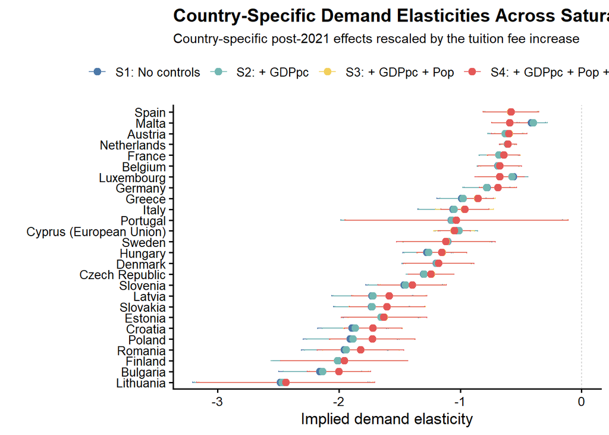

```r
library(purrr)

# Reuse the fee scalars defined earlier. Structural elasticity divides the
# country effect by the LOG fee change (about 0.875).
elas_models <- list(
  "S1: No controls" = s1,
  "S2: + GDPpc" = s2,
  "S3: + GDPpc + Pop" = s3,
  "S4: + GDPpc + Pop + YouthUnempl" = s4
)

elas_coef <- imap_dfr(elas_models, function(mod, mod_name) {
  tidy(mod, conf.int = TRUE) %>%
    mutate(model = mod_name, term = as.character(term)) %>%
    filter(str_detect(term, "treated_factor")) %>%
    mutate(
      country = term %>%
        str_remove(".*treated_factor::") %>%
        str_remove("[#:]Post.*")
    ) %>%
    filter(country != "CONTROL") %>%
    mutate(
      elasticity = estimate  / log_fee_change,
      elas_low   = conf.low  / log_fee_change,
      elas_high  = conf.high / log_fee_change
    )
})

country_order <- elas_coef %>%
  filter(model == "S4: + GDPpc + Pop + YouthUnempl") %>%
  arrange(elasticity) %>%
  pull(country)

elas_plot <- elas_coef %>%
  mutate(
    country = factor(country, levels = country_order),
    model = factor(model, levels = c(
      "S1: No controls", "S2: + GDPpc",
      "S3: + GDPpc + Pop", "S4: + GDPpc + Pop + YouthUnempl"
    ))
  )

ggplot(elas_plot, aes(x = elasticity, y = country, color = model, group = country)) +
  geom_line(color = "grey75", linewidth = 0.5) +
  geom_errorbarh(aes(xmin = elas_low, xmax = elas_high),
                 height = 0.12, linewidth = 0.5, alpha = 0.85) +
  geom_point(size = 2.4) +
  geom_vline(xintercept = 0, linetype = "dashed", color = "grey70", linewidth = 0.35) +
  scale_color_manual(values = c(
    "S1: No controls" = "#4C78A8",
    "S2: + GDPpc" = "#72B7B2",
    "S3: + GDPpc + Pop" = "#F2CF5B",
    "S4: + GDPpc + Pop + YouthUnempl" = "#E45756"
  ), name = NULL) +
  labs(
    title = "Country-Specific Demand Elasticities Across Saturated DiD Specifications",
    subtitle = "Country-specific post-2021 effects rescaled by the tuition fee increase",
    x = "Implied demand elasticity",
    y = ""
  ) +
  theme_classic(base_size = 13) +
  theme(
    plot.title = element_text(face = "bold", size = 15),
    plot.subtitle = element_text(size = 11),
    axis.text.y = element_text(size = 10),
    legend.position = "top",
    legend.text = element_text(size = 10)
  )
```

#Models for step 3

```r
library(broom)
library(openxlsx)

# the four models, named so the sheet tabs read cleanly
model_list <- list(
  m_sat_DK  = m_sat_DK,
  m_sat_DK2 = m_sat_DK2,
  m_sat_DK3 = m_sat_DK3,
  s4        = s4
)

wb <- createWorkbook()

for (nm in names(model_list)) {
  tab <- tidy(model_list[[nm]], conf.int = TRUE)
  addWorksheet(wb, nm)
  writeData(wb, nm, tab)
}

saveWorkbook(wb, "saturated_models.xlsx", overwrite = TRUE)
```

# Descriptives

```r
library(dplyr)
library(tidyr)
library(openxlsx)

# If your object is named panel_sat_wb instead
if (!exists("panel_wb_sat") && exists("panel_sat_wb")) {
  panel_wb_sat <- panel_sat_wb
}

compact_desc <- function(data, dataset_name, year_min, year_max, vars_keep = NULL) {

  data_use <- data %>%
    filter(Year >= year_min, Year <= year_max)

  if (is.null(vars_keep)) {
    vars_keep <- names(data_use)
  }

  vars_keep <- intersect(vars_keep, names(data_use))

  structure_rows <- tibble(
    Dataset = dataset_name,
    Variable = c(
      "Observations",
      "Countries",
      "Years",
      "Treated country-years",
      "Control country-years"
    ),
    N = c(
      nrow(data_use),
      n_distinct(data_use$Domicile_named_country),
      n_distinct(data_use$Year),
      if ("EU" %in% names(data_use)) sum(data_use$EU == 1, na.rm = TRUE) else NA_real_,
      if ("EU" %in% names(data_use)) sum(data_use$EU == 0, na.rm = TRUE) else NA_real_
    ),
    Mean = NA_real_,
    SD = NA_real_,
    Min = NA_real_,
    Median = NA_real_,
    Max = NA_real_
  )

  numeric_rows <- data_use %>%
    select(any_of(vars_keep)) %>%
    select(where(is.numeric)) %>%
    pivot_longer(everything(), names_to = "Variable", values_to = "value") %>%
    group_by(Variable) %>%
    summarise(
      Dataset = dataset_name,
      N = sum(!is.na(value)),
      Mean = mean(value, na.rm = TRUE),
      SD = sd(value, na.rm = TRUE),
      Min = min(value, na.rm = TRUE),
      Median = median(value, na.rm = TRUE),
      Max = max(value, na.rm = TRUE),
      .groups = "drop"
    ) %>%
    select(Dataset, Variable, N, Mean, SD, Min, Median, Max)

  bind_rows(structure_rows, numeric_rows) %>%
    mutate(
      across(c(Mean, SD, Min, Median, Max), ~ round(.x, 3))
    )
}

main_vars <- c(
  "Applicants",
  "log_app",
  "Year",
  "EU",
  "Post",
  "event_time",
  "regression_weight"
)

wb_vars <- c(
  "Applicants",
  "log_app",
  "Year",
  "EU",
  "Post",
  "event_time",
  "regression_weight",
  "gdp_pc",
  "log_gdp_pc",
  "log_gdp_pc_c",
  "pop_15_64",
  "log_pop_15_64",
  "log_pop_15_64_c",
  "youth_unemp",
  "youth_unemp_c",
  "educ_spend",
  "educ_spend_c"
)

desc_panel_main <- compact_desc(
  panel_main,
  "panel_main, full applicant panel, 2016–2025",
  2016,
  2025,
  main_vars
)

desc_panel_wb_sat <- compact_desc(
  panel_wb_sat,
  "panel_wb_sat, World Bank matched panel, 2016–2024",
  2016,
  2024,
  wb_vars
)

desc_table <- bind_rows(
  desc_panel_main,
  desc_panel_wb_sat
)

wb <- createWorkbook()

addWorksheet(wb, "Compact descriptives")
writeData(wb, "Compact descriptives", desc_table)

addWorksheet(wb, "panel_main")
writeData(wb, "panel_main", desc_panel_main)

addWorksheet(wb, "panel_wb_sat")
writeData(wb, "panel_wb_sat", desc_panel_wb_sat)

header_style <- createStyle(
  textDecoration = "bold",
  halign = "center",
  border = "Bottom"
)

for (sh in names(wb)) {
  addStyle(
    wb,
    sheet = sh,
    style = header_style,
    rows = 1,
    cols = 1:ncol(desc_table),
    gridExpand = TRUE
  )
  setColWidths(wb, sheet = sh, cols = 1:ncol(desc_table), widths = "auto")
  freezePane(wb, sheet = sh, firstRow = TRUE)
}

saveWorkbook(
  wb,
  file = "compact_descriptives.xlsx",
  overwrite = TRUE
)
```

# Standalone synthetic difference-in-differences on the full donor pool

This section stands apart from the rest of the manuscript. It does not feed any headline number and it ignores the curated synthetic control weights used earlier. The point is narrow. It asks what a single synthetic difference-in-differences estimate looks like when every non-EU country in the cleaned file is thrown into the donor pool at once, with no hand-picked controls and no regression weighting. The estimator follows Arkhangelsky et al. (2021) and runs through the synthdid package, which blends synthetic control unit weights with difference-in-differences time weights in one step.

The synthdid package lives on GitHub, not CRAN, so it needs a one-time install with devtools before the library call.

The estimator needs three things. A balanced panel where every unit appears in every year, one common adoption date shared by all treated units, and a clean 0/1 treatment indicator that switches on for treated units in treated years. The EU block all move together in 2021, so the block design holds. We start from apps_clean, drop any country whose applicant count hits zero in some year (its log outcome is not finite), then keep only countries observed in every year so the panel is balanced.

```r
library(synthdid)
library(dplyr)

# Years included in the analysis
all_years <- sort(unique(apps_clean$Year))
n_years <- length(all_years)

# Construct one observation per country and year
sdid_long <- apps_clean %>%
  select(
    Domicile_named_country,
    Year,
    log_app,
    EU
  ) %>%
  filter(
    !is.na(Domicile_named_country),
    !is.na(Year),
    !is.na(EU)
  ) %>%
  group_by(Domicile_named_country, Year) %>%
  summarise(
    log_app = mean(log_app, na.rm = TRUE),
    EU = first(EU),
    n_EU_values = n_distinct(EU),
    .groups = "drop"
  )

# Stop if the same country has conflicting EU classifications
stopifnot(all(sdid_long$n_EU_values == 1))

sdid_long <- sdid_long %>%
  select(-n_EU_values)

# Remove any country with a non-finite outcome in at least one year
bad_countries <- sdid_long %>%
  group_by(Domicile_named_country) %>%
  summarise(
    bad_outcome = any(!is.finite(log_app)),
    .groups = "drop"
  ) %>%
  filter(bad_outcome) %>%
  pull(Domicile_named_country)

sdid_long <- sdid_long %>%
  filter(!Domicile_named_country %in% bad_countries)

# Keep only countries observed exactly once in every analysis year
sdid_long <- sdid_long %>%
  group_by(Domicile_named_country) %>%
  filter(
    n() == n_years,
    n_distinct(Year) == n_years,
    all(all_years %in% Year)
  ) %>%
  ungroup()

# Treatment starts for EU countries in 2021
sdid_long <- sdid_long %>%
  mutate(
    treated = as.integer(EU == 1 & Year >= 2021)
  ) %>%
  arrange(Domicile_named_country, Year)

# Strict balance checks
stopifnot(
  !anyDuplicated(
    sdid_long[c("Domicile_named_country", "Year")]
  )
)

stopifnot(
  nrow(sdid_long) ==
    n_distinct(sdid_long$Domicile_named_country) *
    n_distinct(sdid_long$Year)
)

stopifnot(
  all(is.finite(sdid_long$log_app))
)

# Sanity checks
n_distinct(
  sdid_long$Domicile_named_country[sdid_long$EU == 0]
)
```

```
## [1] 161
```

```r
n_distinct(
  sdid_long$Domicile_named_country[sdid_long$EU == 1]
)
```

```
## [1] 26
```

```r
range(sdid_long$Year)
```

```
## [1] 2016 2025
```

```r
sdid_long %>%
  count(Domicile_named_country) %>%
  summarise(
    minimum_years = min(n),
    maximum_years = max(n)
  )
```

| minimum_years | maximum_years |
| --- | --- |
| 10 | 10 |

```r
# Convert the long panel into synthdid matrices
setup <- panel.matrices(
  as.data.frame(sdid_long),
  unit = "Domicile_named_country",
  time = "Year",
  outcome = "log_app",
  treatment = "treated"
)

# Number of control units and pre-treatment periods
setup$N0
```

```
## [1] 161
```

```r
setup$T0
```

```
## [1] 5
```

Now hand the long panel to panel.matrices, which reshapes it into the wide outcome matrix the estimator expects and reports the number of control units N0 and the number of pre-treatment periods T0.

```r
setup <- panel.matrices(
  as.data.frame(sdid_long),
  unit      = "Domicile_named_country",
  time      = "Year",
  outcome   = "log_app",
  treatment = "treated"
)

# how many donors and how many pre-periods the estimator is working with
setup$N0
```

```
## [1] 161
```

```r
setup$T0
```

```
## [1] 5
```

The estimate is one line. Standard errors come from the jackknife, which is the right choice here because the treated group holds many units. The placebo variant shown in the package documentation is meant for the single treated unit case and does not apply.

```r
tau_hat <- synthdid_estimate(setup$Y, setup$N0, setup$T0)

se <- sqrt(vcov(tau_hat, method = "jackknife"))

summary(tau_hat)
```

```
## $estimate
## [1] -1.227506
##
## $se
##           [,1]
## [1,] 0.1011385
##
## $controls
##                                    estimate 1
## South Sudan                             0.011
## Paraguay                                0.011
## Angola                                  0.010
## Yemen                                   0.010
## Eswatini                                0.010
## Cyprus (Non-European Union)             0.010
## St Lucia                                0.010
## Lesotho                                 0.009
## Montserrat                              0.009
## Uruguay                                 0.009
## Venezuela (Bolivarian Republic of)      0.009
## Anguilla                                0.009
## Faroe Islands                           0.009
## Dominica                                0.008
## Bermuda                                 0.008
## Bosnia and Herzegovina                  0.008
## Montenegro                              0.008
## Israel                                  0.008
## Colombia                                0.008
## Russian Federation                      0.008
## Serbia                                  0.008
## Bahamas                                 0.008
## Malaysia                                0.008
## Iraq                                    0.008
## Guernsey                                0.008
## Trinidad and Tobago                     0.008
## Turks and Caicos Islands                0.008
## Brunei Darussalam                       0.008
## Mauritius                               0.008
## North Macedonia                         0.008
## Saint Vincent and the Grenadines        0.008
```

[output cut: 97 more lines]

```
## Lao PDR                                 0.005
## Seychelles                              0.005
## Bolivia                                 0.005
## Nepal                                   0.005
## Ghana                                   0.005
## Cameroon                                0.005
##
## $periods
##      estimate 1
## 2020      0.846
## 2019      0.122
##
## $dimensions
##           N1           N0 N0.effective           T1           T0 T0.effective
##       26.000      161.000      149.309        5.000        5.000        1.365
```

```r
sprintf("point estimate %.3f", as.numeric(tau_hat))
```

```
## [1] "point estimate -1.228"
```

```r
sprintf("95%% CI (%.3f, %.3f)", tau_hat - 1.96 * se, tau_hat + 1.96 * se)
```

```
## [1] "95% CI (-1.433, -1.022)"
```

The plot overlays the treated EU trajectory against its synthetic counterpart and marks the pre-period time weights along the bottom.

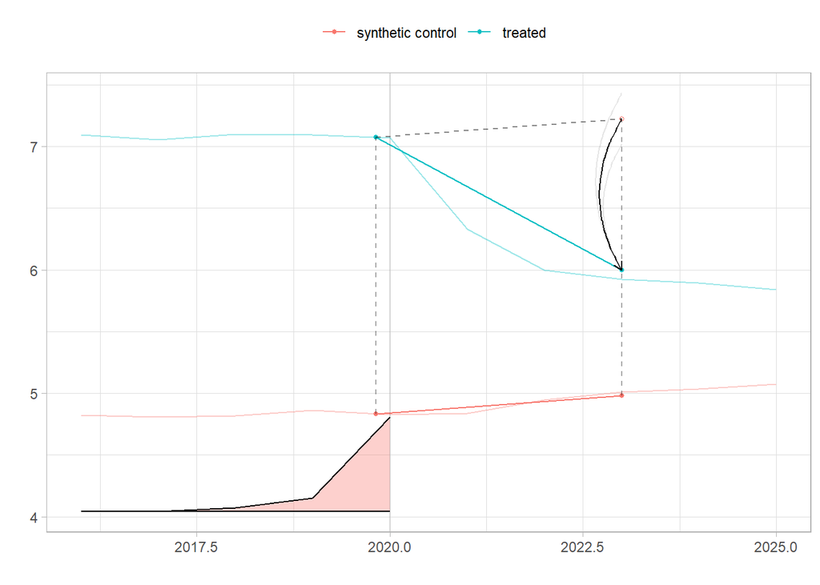

```r
plot(tau_hat)
```

The coefficient sits on the log applicant scale, so it reads as an approximate proportional change in EU postgraduate applications attributed to the 2021 fee reform, now identified against the widest available donor pool instead of a curated set. Treat it as a stress test. If the sign and rough magnitude survive when the controls are chosen mechanically by the estimator across every available country, the headline result is not an artifact of the donor selection made elsewhere in the manuscript.

## Reference

Arkhangelsky, D., Athey, S., Hirshberg, D. A., Imbens, G. W., & Wager, S. (2021). Synthetic difference-in-differences. American Economic Review, 111(12), 4088–4118. https://doi.org/10.1257/aer.20190159